# מבוא ללמידה עמוקה – מטלת בית 1

## Afeka College of Engineering

### Semester B, 2026

**סטודנטים:**

- אביעד צפרי – 322281452
- דוד אזימוב – 205697592

## Question 1:

### נתון הPerceptron הבא:

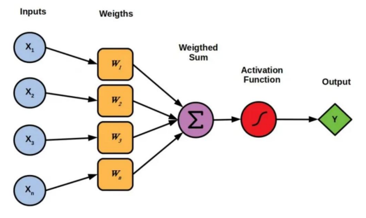

א. כתוב ביטוי מתמטי המתאר את הפלט $(Y)$ כפונקציה של 4 הקלטים וארבעת המשקלים $(w_i)$ .  
השתמש בפונקציית אקטיבציה סיגמואיד

ב. גזור את הביטוי שכתבת בסעיף א' ביחס לכל אחד מהמשקלים wi.

ג. הנח שכל אחד מהמשתנים xi נמצא בטווח [1.0 0.0,], וגם כל אחד מהמשקלים wi נמצא באותו הטווח. בחר את אחד מארבעת הקלטים כמשתנה חופשי ועבור כל אחד משלושת הקלטים האחרים בחר ערך ראנדומלי בתוך הטווח. בחר ערך ראנדומלי עבור כל אחד מהמשקלים. שרטט את Y כפונקציה של השתנות הקלט.

ד. עבור הערכים שבחרת בסעיף ג' – שרטט את הנגזרת של Y כפונקציה של השתנות הקלט שבחרת בסעיף ג'.

ה. חזור על סעיפים ג וד – אלא שהפעם בחר ערכים ראנדומאליים עבור כל אחד מהקלטים. בחר משקל אחד שיהיה משתנה חופשי. עבור 3 המשקלים הנותרים בחר ערכים ראנדומליים. שרטט את ערך הפונקציה Y לפי השתנות המשקל שנבחר להיות משתנה חופשי. שרטט את ערך הנגזרת כפונק' של אותו המשתנה.

ו. שנה את פונקציית האקטיבציה להיות TANH וחזור על סעיפים א -ה עבור פונקצייה זו.

ז. השווה את התוצאות שקיבלת עבור הפונקציה סיגמואיד לאלו שהתקבלו עבור TANH

## Answer 1

#### **א. ביטוי מתמטי עבור הפלט**

נסמן את הסכום המשוקלל של הקלטים כך:

$$ z = w_1x_1 + w_2x_2 + w_3x_3 + w_4x_4 $$

מכיוון שפונקציית האקטיבציה היא סיגמואיד, הפלט $Y$ הוא:

$$ Y = \sigma(z) $$

כאשר:

$$ \sigma(z)=\frac{1}{1+e^{-z}} $$

ולכן הביטוי המלא הוא:

$$ Y = \frac{1}{1 + e^{-(w_1x_1 + w_2x_2 + w_3x_3 + w_4x_4)}} $$

#### **ב. גזירת הביטוי ביחס לכל אחד מהמשקלים**

מהסעיף הקודם:

$$ Y = \sigma(z) $$

כאשר:

$$ z = \sum_{i=1}^{4} w_i x_i = w_1x_1+w_2x_2+w_3x_3+w_4x_4 $$

ופונקציית הסיגמואיד היא:

$$ \sigma(z)=\frac{1}{1+e^{-z}} $$

לכן ניתן לכתוב את הפלט בצורה מפורשת:

$$ Y = \frac{1}{1+e^{-\sum_{i=1}^{4} w_i x_i}} $$

כדי לגזור את $Y$ ביחס למשקל $w_i$, נשתמש בכלל השרשרת:

$$ \frac{\partial Y}{\partial w_i} = \frac{d\sigma(z)}{dz} \cdot \frac{\partial z}{\partial w_i} $$

נגזרת הסיגמואיד היא:

$$ \frac{d\sigma(z)}{dz} = \sigma(z)\left(1-\sigma(z)\right) $$

ומכיוון ש:

$$ Y=\sigma(z) $$

נקבל:

$$ \frac{dY}{dz} = Y(1-Y) $$

בנוסף:

$$ \frac{\partial z}{\partial w_i} = \frac{\partial}{\partial w_i} \left( \sum_{j=1}^{4} w_j x_j \right) = x_i $$

לכן:

$$ \boxed{ \frac{\partial Y}{\partial w_i} = x_i Y(1-Y) } $$

עבור $i=1,2,3,4$.

כלומר, באופן מפורש:

$$ \frac{\partial Y}{\partial w_1} = x_1Y(1-Y) $$

$$ \frac{\partial Y}{\partial w_2} = x_2Y(1-Y) $$

$$ \frac{\partial Y}{\partial w_3} = x_3Y(1-Y) $$

$$ \frac{\partial Y}{\partial w_4} = x_4Y(1-Y) $$

אפשר גם לכתוב את הנגזרת בצורה מפורשת ללא שימוש ב-$Y$:

$$ \boxed{ \frac{\partial Y}{\partial w_i} = x_i \cdot \frac{e^{-z}}{\left(1+e^{-z}\right)^2} } $$

כאשר:

$$ z = \sum_{j=1}^{4} w_jx_j $$

ולכן:

$$ \boxed{ \frac{\partial Y}{\partial w_i} = x_i \cdot \frac{ e^{-\sum_{j=1}^{4} w_jx_j} }{ \left( 1+e^{-\sum_{j=1}^{4} w_jx_j} \right)^2 } } $$

#### **ג. שרטוט הפלט כפונקציה של קלט משתנה**

בסעיף זה נבחר את $x_1$ להיות המשתנה החופשי, כלומר:

$$ x_1 \in [0,1] $$

שלושת הקלטים האחרים נבחרים כערכים קבועים ורנדומליים מתוך התחום $[0,1]$:

$$ x_2, x_3, x_4 \sim U(0,1) $$

בנוסף, כל ארבעת המשקלים נבחרים כערכים רנדומליים מתוך התחום $[0,1]$:

$$ w_1,w_2,w_3,w_4 \sim U(0,1) $$

לכן, עבור $x_1$ משתנה, הסכום המשוקלל הוא:

$$ z(x_1) = w_1x_1+w_2x_2+w_3x_3+w_4x_4 $$

והפלט של הנוירון הוא:

כלומר:

$$ Y(x_1) = \frac{1}{1+e^{-(w_1x_1+w_2x_2+w_3x_3+w_4x_4)}} $$

כעת נשרטט את $Y$ כפונקציה של $x_1$ בתחום $[0,1]$.

```python
# Install all required packages for exercises
%pip install -q numpy pandas matplotlib seaborn scikit-learn ISLP
```

```
x2 = 0.3745, x3 = 0.9507, x4 = 0.7320
w1 = 0.5987, w2 = 0.1560, w3 = 0.1560, w4 = 0.0581
```

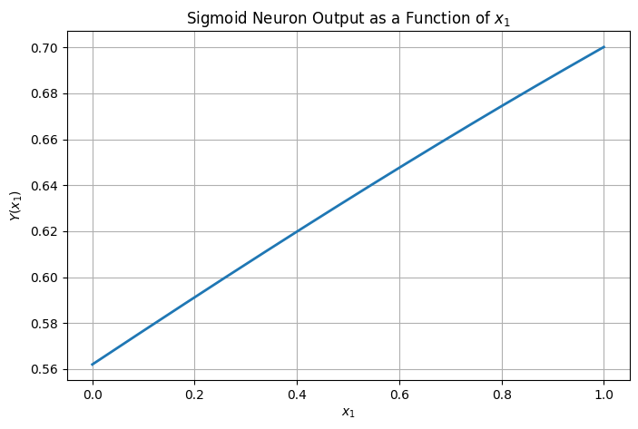

```python
import numpy as np
import matplotlib.pyplot as plt

# For reproducibility
np.random.seed(42)

# Free input
x1_values = np.linspace(0, 1, 300)

# Random fixed inputs: x2, x3, x4
x2, x3, x4 = np.random.uniform(0, 1, 3)

# Random weights: w1, w2, w3, w4
w1, w2, w3, w4 = np.random.uniform(0, 1, 4)

def sigmoid(z):
    return 1 / (1 + np.exp(-z))

# Weighted sum as a function of x1
z_values = w1 * x1_values + w2 * x2 + w3 * x3 + w4 * x4

# Neuron output
Y_values = sigmoid(z_values)

print(f"x2 = {x2:.4f}, x3 = {x3:.4f}, x4 = {x4:.4f}")
print(f"w1 = {w1:.4f}, w2 = {w2:.4f}, w3 = {w3:.4f}, w4 = {w4:.4f}")

plt.figure(figsize=(8, 5))
plt.plot(x1_values, Y_values, linewidth=2)
plt.xlabel(r"$x_1$")
plt.ylabel(r"$Y(x_1)$")
plt.title(r"Sigmoid Neuron Output as a Function of $x_1$")
plt.grid(True)
plt.show()
```

#### **ד. שרטוט הנגזרת של הפלט כפונקציה של הקלט המשתנה**

בסעיף ג' בחרנו את $x_1$ כמשתנה החופשי, ולכן כעת נחשב את הנגזרת של הפלט $Y$ ביחס ל-$x_1$.

מהסעיף הקודם:

$$ Y(x_1)=\sigma(z(x_1)) $$

כאשר:

$$ z(x_1)=w_1x_1+w_2x_2+w_3x_3+w_4x_4 $$

נגזור לפי $x_1$ באמצעות כלל השרשרת:

$$ \frac{dY}{dx_1} = \frac{d\sigma(z)}{dz} \cdot \frac{dz}{dx_1} $$

נגזרת הסיגמואיד היא:

$$ \frac{d\sigma(z)}{dz} = \sigma(z)(1-\sigma(z)) $$

ומכיוון ש:

$$ Y=\sigma(z) $$

נקבל:

$$ \frac{dY}{dz} = Y(1-Y) $$

בנוסף:

$$ \frac{dz}{dx_1}=w_1 $$

ולכן:

$$ \boxed{ \frac{dY}{dx_1} = w_1Y(1-Y) } $$

כלומר, הנגזרת של הפלט ביחס לקלט המשתנה תלויה גם במשקל המתאים לאותו קלט, $w_1$, וגם בערך הפלט עצמו.

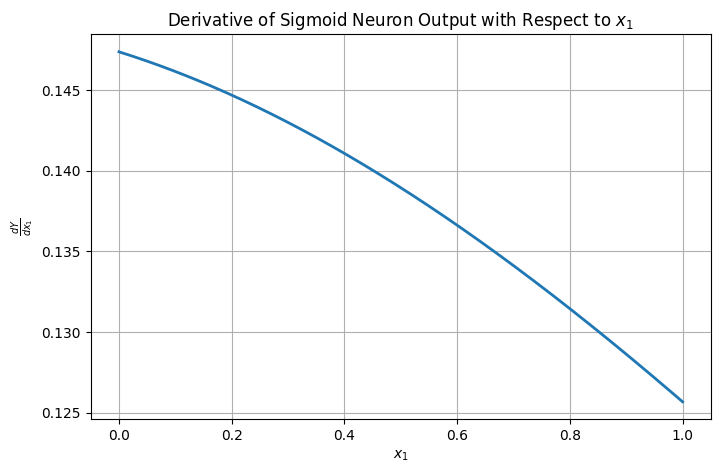

```python
# Derivative of Y with respect to the free input x1
dY_dx1_values = w1 * Y_values * (1 - Y_values)

plt.figure(figsize=(8, 5))
plt.plot(x1_values, dY_dx1_values, linewidth=2)
plt.xlabel(r"$x_1$")
plt.ylabel(r"$\frac{dY}{dx_1}$")
plt.title(r"Derivative of Sigmoid Neuron Output with Respect to $x_1$")
plt.grid(True)
plt.show()
```

#### **ה. משתנה משקולת חופשי**

הפעם נחזור על סעיפים ג' ו-ד' כאשר נבחר משקולת אחת שתהייה משתנה חופשי  
.שאר הערכים (קלטים ומשקולות) יהיו ראנדומאליים

במקרה זה נקבל כי:

$$ \frac{dY}{dw_1} = \frac{d\sigma(z)}{dz} \cdot \frac{dz}{dw_1} $$

נגזרת הסיגמואיד היא:

$$ \frac{d\sigma(z)}{dz} = \sigma(z)(1-\sigma(z)) $$

ומכיוון ש:

$$ Y=\sigma(z) $$

נקבל:

$$ \frac{dY}{dz} = Y(1-Y) $$

בנוסף:

$$ \frac{dz}{dw_1}=x_1 $$

ולכן:

$$ \boxed{ \frac{dY}{dw_1} = x_1Y(1-Y) } $$

כלומר, הנגזרת של הפלט ביחס למשקולת המשתנה תלויה גם בקלט המתאים לאותה משקולת, $w_1$, וגם בערך הפלט עצמו.

```
x1 = 0.1151, x2 = 0.6091, x3 = 0.1334, x4 = 0.2406
w2 = 0.3271, w3 = 0.8591, w4 = 0.6661
```

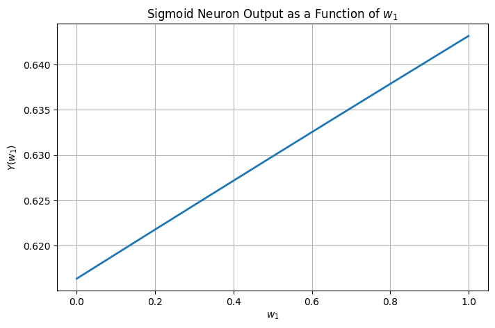

```python
np.random.seed(43)

# Free input
w1_values = np.linspace(0, 1, 300)

# Random fixed inputs: x1, x2, x3, x4
x1, x2, x3, x4 = np.random.uniform(0, 1, 4)

# Random weights: w2, w3, w4
w2, w3, w4 = np.random.uniform(0, 1, 3)

def sigmoid(z):
    return 1 / (1 + np.exp(-z))

# Weighted sum as a function of w1
z_values = w1_values * x1 + w2 * x2 + w3 * x3 + w4 * x4

# Neuron output
Y_values = sigmoid(z_values)

print(f"x1 = {x1:.4f}, x2 = {x2:.4f}, x3 = {x3:.4f}, x4 = {x4:.4f}")
print(f"w2 = {w2:.4f}, w3 = {w3:.4f}, w4 = {w4:.4f}")

plt.figure(figsize=(8, 5))
plt.plot(w1_values, Y_values, linewidth=2)
plt.xlabel(r"$w_1$")
plt.ylabel(r"$Y(w_1)$")
plt.title(r"Sigmoid Neuron Output as a Function of $w_1$")
plt.grid(True)
plt.show()
```

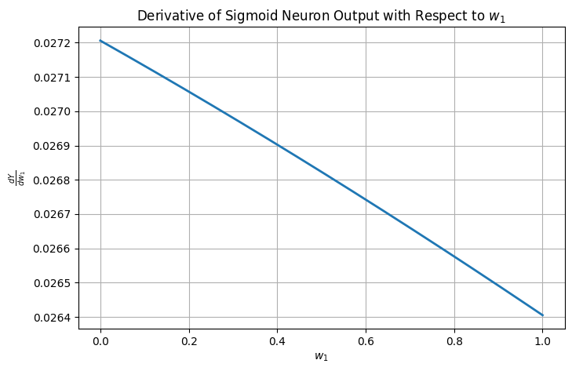

```python
# Derivative of Y with respect to the free input w1
dY_dw1_values = x1 * Y_values * (1 - Y_values)

plt.figure(figsize=(8, 5))
plt.plot(w1_values, dY_dw1_values, linewidth=2)
plt.xlabel(r"$w_1$")
plt.ylabel(r"$\frac{dY}{dw_1}$")
plt.title(r"Derivative of Sigmoid Neuron Output with Respect to $w_1$")
plt.grid(True)
plt.show()
```

#### **TANH ו. פונקצית אקטיבציה**

##### **1. ביטוי מתמטי עבור הפלט**

נסמן את הסכום המשוקלל של הקלטים כך:

$$ z = w_1x_1 + w_2x_2 + w_3x_3 + w_4x_4 $$

מכיוון שפונקציית האקטיבציה היא היפרבולית, הפלט $Y$ הוא:

$$ Y = \phi(z) =TANH(z) $$

כאשר:

$$ \phi(z)=TANH(z)=\frac{e^{2z}-1}{e^{2z}+1} $$

ולכן הביטוי המלא הוא:

$$ Y = \frac{e^{2(w_1x_1 + w_2x_2 + w_3x_3 + w_4x_4)}-1}{e^{2(w_1x_1 + w_2x_2 + w_3x_3 + w_4x_4)}+1} $$

##### **2. גזירת הביטוי ביחס לכל אחד מהמשקלים**

כדי לגזור את $Y$ ביחס למשקל $w_i$, נשתמש בכלל השרשרת:

$$ \frac{\partial Y}{\partial w_i} = \frac{d\phi(z)}{dz} \cdot \frac{\partial z}{\partial w_i} $$

$$ \frac{d\phi(z)}{dz} = 1 - \phi^2(z) $$

נגזרת TANH היא:

$$ \frac{d TANH(z)}{dz} = 1 - TANH^2(z)=1 - \phi^2(z) $$

ומכיוון ש:

$$ Y=\phi(z) $$

נקבל:

$$ \frac{dY(z)}{dz} = 1 - Y^2(z)= 1-(\frac{e^{2z}-1}{e^{2z}+1})^2=\frac{4e^{2z}}{(e^{2z}+1)^2} $$

בנוסף:

$$ \frac{\partial z}{\partial w_i} = \frac{\partial}{\partial w_i} \left( \sum_{j=1}^{4} w_j x_j \right) = x_i $$

לכן:

$$ \boxed{ \frac{\partial Y}{\partial w_i} = x_i*\frac{4e^{2z}}{(e^{2z}+1)^2} } $$

עבור $i=1,2,3,4$.

כלומר, באופן מפורש:

$$ \frac{\partial Y}{\partial w_1} = x_1*\frac{4e^{2z}}{(e^{2z}+1)^2} $$

$$ \frac{\partial Y}{\partial w_2} = x_2*\frac{4e^{2z}}{(e^{2z}+1)^2} $$

$$ \frac{\partial Y}{\partial w_3} = x_3*\frac{4e^{2z}}{(e^{2z}+1)^2} $$

$$ \frac{\partial Y}{\partial w_4} = x_4*\frac{4e^{2z}}{(e^{2z}+1)^2} $$

אפשר גם לכתוב את הנגזרת בצורה מפורשת ללא שימוש ב-$Y$:

$$ \boxed{ \frac{\partial Y}{\partial w_i} = x_i \cdot \frac{4e^{2z}}{(e^{2z}+1)^2} } $$

כאשר:

$$ z = \sum_{j=1}^{4} w_jx_j $$

ולכן:

$$ \boxed{ \frac{\partial Y}{\partial w_i} = x_i \cdot \frac{4e^{2\cdot\sum_{j=1}^{4} w_jx_j}}{(e^{2\cdot\sum_{j=1}^{4} w_jx_jz}+1)^2} = x_i \cdot \frac{4e^{2\cdot(w_1x_1 + w_2x_2 + w_3x_3 + w_4x_4)}}{(e^{2\cdot(w_1x_1 + w_2x_2 + w_3x_3 + w_4x_4)}+1)^2} } $$

##### **3. שרטוט הפלט כפונקציה של קלט משתנה**

בסעיף זה נבחר את $x_1$ להיות המשתנה החופשי, כלומר:

$$ x_1 \in [0,1] $$

שלושת הקלטים האחרים נבחרים כערכים קבועים ורנדומליים מתוך התחום $[0,1]$:

$$ x_2, x_3, x_4 \sim U(0,1) $$

בנוסף, כל ארבעת המשקלים נבחרים כערכים רנדומליים מתוך התחום $[0,1]$:

$$ w_1,w_2,w_3,w_4 \sim U(0,1) $$

```
x2 = 0.3745, x3 = 0.9507, x4 = 0.7320
w1 = 0.5987, w2 = 0.1560, w3 = 0.1560, w4 = 0.0581
```

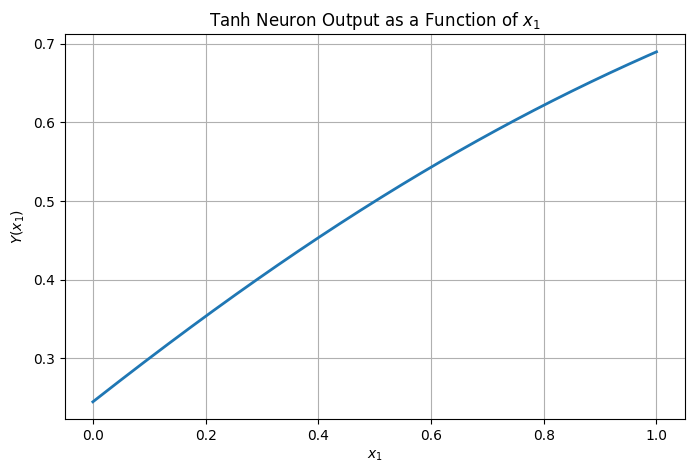

```python
# For reproducibility
np.random.seed(42)

# Free input
x1_values = np.linspace(0, 1, 300)

# Random fixed inputs: x2, x3, x4
x2, x3, x4 = np.random.uniform(0, 1, 3)

# Random weights: w1, w2, w3, w4
w1, w2, w3, w4 = np.random.uniform(0, 1, 4)

def tanh(z):
    return (np.exp(2*z) - 1) / (np.exp(2*z) + 1)

# Weighted sum as a function of x1
z_values = w1 * x1_values + w2 * x2 + w3 * x3 + w4 * x4

# Neuron output
Y_values = tanh(z_values)

print(f"x2 = {x2:.4f}, x3 = {x3:.4f}, x4 = {x4:.4f}")
print(f"w1 = {w1:.4f}, w2 = {w2:.4f}, w3 = {w3:.4f}, w4 = {w4:.4f}")

plt.figure(figsize=(8, 5))
plt.plot(x1_values, Y_values, linewidth=2)
plt.xlabel(r"$x_1$")
plt.ylabel(r"$Y(x_1)$")
plt.title(r"Tanh Neuron Output as a Function of $x_1$")
plt.grid(True)
plt.show()
```

##### **4. שרטוט הנגזרת של הפלט כפונקציה של הקלט המשתנה**

בסעיף ה.3. בחרנו את $x_1$ כמשתנה החופשי, ולכן כעת נחשב את הנגזרת של הפלט $Y$ ביחס ל-$x_1$.

מהסעיף הקודם:

$$ Y(x_1)=\phi(z(x_1)) $$

כאשר:

$$ z(x_1)=w_1x_1+w_2x_2+w_3x_3+w_4x_4 $$

נגזור לפי $x_1$ באמצעות כלל השרשרת:

$$ \frac{dY}{dx_1} = \frac{dY(z)}{dz} \cdot \frac{dz}{dx_1} $$

כזכור:

$$ \frac{dY}{dz} = 1-Y^2 $$

בנוסף:

$$ \frac{dz}{dx_1}=w_1 $$

ולכן:

$$ \boxed{ \frac{dY}{dx_1} = w_1\cdot (1-Y^2) } $$

כלומר, הנגזרת של הפלט ביחס לקלט המשתנה תלויה גם במשקל המתאים לאותו קלט, $w_1$, וגם בערך הפלט עצמו.

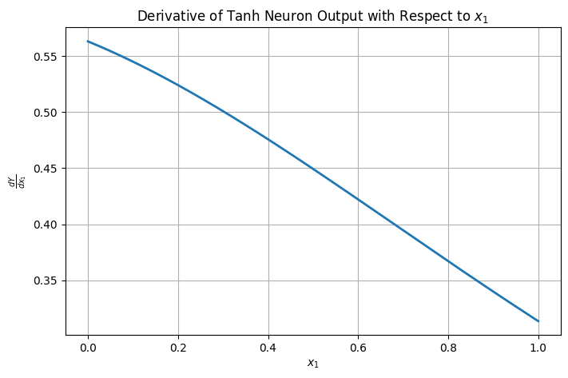

```python
# Derivative of Y with respect to the free input x1
dY_dx1_values = w1 * (1 - Y_values**2)

plt.figure(figsize=(8, 5))
plt.plot(x1_values, dY_dx1_values, linewidth=2)
plt.xlabel(r"$x_1$")
plt.ylabel(r"$\frac{dY}{dx_1}$")
plt.title(r"Derivative of Tanh Neuron Output with Respect to $x_1$")
plt.grid(True)
plt.show()
```

#### **5. משתנה משקולת חופשי**

הפעם נחזור על סעיפים ה.3. ו-ה.4. כאשר נבחר משקולת אחת שתהייה משתנה חופשי  
.שאר הערכים (קלטים ומשקולות) יהיו ראנדומאליים

במקרה זה נקבל כי:

$$ \frac{dY}{dw_1} = \frac{dY(z)}{dz} \cdot \frac{dz}{dw_1} $$

כזכור:

$$ \frac{dY}{dz} = 1-Y^2 $$

בנוסף:

$$ \frac{dz}{dw_1}=x_1 $$

ולכן:

$$ \boxed{ \frac{dY}{dw_1} = x_1\cdot (1-Y^2) } $$

כלומר, הנגזרת של הפלט ביחס למשקולת המשתנה תלויה גם בקלט המתאים לאותה משקולת, $w_1$, וגם בערך הפלט עצמו.

```
x1 = 0.1151, x2 = 0.6091, x3 = 0.1334, x4 = 0.2406
w2 = 0.3271, w3 = 0.8591, w4 = 0.6661
```

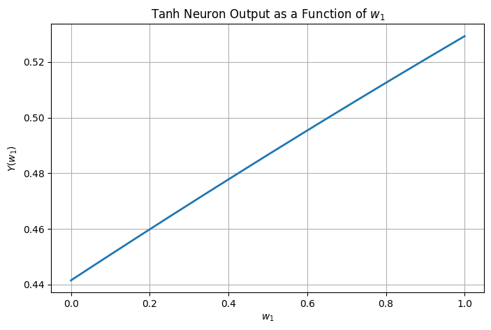

```python
np.random.seed(43)

# Free input
w1_values = np.linspace(0, 1, 300)

# Random fixed inputs: x1, x2, x3, x4
x1, x2, x3, x4 = np.random.uniform(0, 1, 4)

# Random weights: w2, w3, w4
w2, w3, w4 = np.random.uniform(0, 1, 3)

def tanh(z):
    return (np.exp(2*z) - 1) / (np.exp(2*z) + 1)

# Weighted sum as a function of w1
z_values = w1_values * x1 + w2 * x2 + w3 * x3 + w4 * x4

# Neuron output
Y_values = tanh(z_values)

print(f"x1 = {x1:.4f}, x2 = {x2:.4f}, x3 = {x3:.4f}, x4 = {x4:.4f}")
print(f"w2 = {w2:.4f}, w3 = {w3:.4f}, w4 = {w4:.4f}")

plt.figure(figsize=(8, 5))
plt.plot(w1_values, Y_values, linewidth=2)
plt.xlabel(r"$w_1$")
plt.ylabel(r"$Y(w_1)$")
plt.title(r"Tanh Neuron Output as a Function of $w_1$")
plt.grid(True)
plt.show()
```

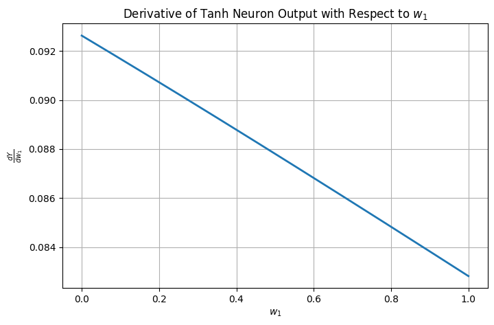

```python
# Derivative of Y with respect to the free input w1
dY_dw1_values = x1 * (1 - Y_values**2)

plt.figure(figsize=(8, 5))
plt.plot(w1_values, dY_dw1_values, linewidth=2)
plt.xlabel(r"$w_1$")
plt.ylabel(r"$\frac{dY}{dw_1}$")
plt.title(r"Derivative of Tanh Neuron Output with Respect to $w_1$")
plt.grid(True)
plt.show()
```

## Question 2:

נתונה הרשת הבאה:

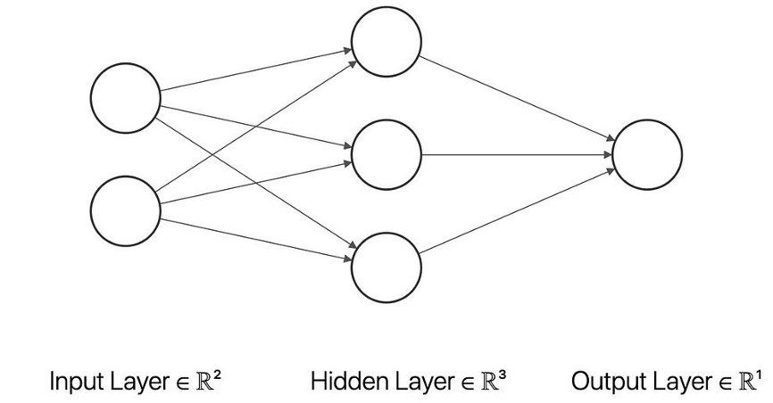

הנח שפונקציית האקטיבציה היא סיגמואיד.  
א . כתוב ביטוי מלא של הפלט כפונקציה של שני הקלטים ושל כל אחת מתשע הקשתות (המשקלים).  
ב . בחר קשת אחת המחברת את ה hidden layer לפלט – וגזור את הפונקציה בסעיף א' ביחס אליה  
ג . בחר קשת אחת המחברת את הקלט ל hidden layer וגזור את הפונקציה בסעיף א – ביחס אליה.  
ד . הוסף לפונקציה בסעיף א '– ביטויים של ה BIASES וגזור אותה עבור אחד מפרמטרי ה BIAS (לבחירתך).  
ה. קבע את הערכים של הקלטים ושל הקשתות למספרים ראנדומליים בטווח [0.0 ,1.0].  
השאר את ערך הקשת שגזרת ביחס אליה בסעיף ג' בתור ערך חופשי ושרטט את הנגזרת כפונקציה של ערך זה.

## Answer 2

#### **א. ביטוי מתמטי עבור הפלט**

במקרה זה קיבלנו רשת נוירונים הבנויה משלושה שכבות:

1. שכבת קלט -  
   שני נוירונים, נסמן אותם כ- $x_1, x_2$
2. שכבה נסתרת -  
   שלושה נוירונים, אליהם מובילות 6 קשתות משכבת הקלט. נסמן אותם כ- $h_1, h_2, h_3$
3. שכבת הפלט -  
   נוירון בודד אליו מובילות 3 קשתות מהשכבה הנסתרת, נסמן אותו כ- $Y$

ביטוי עבור כל נוירון בשכבה 2:

$$ h_i=\sigma (w_{i1}\cdot x_1+w_{i2}\cdot x_2) $$

נקבל כי עבור כלל הנוירונים:

$$ h_1=\sigma (w_{11}\cdot x_1+w_{12}\cdot x_2) $$ $$ h_2=\sigma (w_{21}\cdot x_1+w_{22}\cdot x_2) $$ $$ h_3=\sigma (w_{31}\cdot x_1+w_{32}\cdot x_2) $$

או בכתב מטריציוני:

$$ \begin{equation} \tag{eq1} \begin{pmatrix} h_1 \\ h_2 \\ h_3 \end{pmatrix}= \sigma \left( \begin{pmatrix} w_{11} & w_{12} \\ w_{21} & w_{22} \\ w_{31} & w_{32} \end{pmatrix} \cdot \begin{pmatrix} x_1 \\ x_2 \end{pmatrix} \right) \end{equation} $$

ביטוי עבור הפלט :

$$ \begin{equation} \tag{eq2} Y = \sigma \left( \begin{pmatrix} v_1 & v_2 & v_3 \end{pmatrix} \cdot \begin{pmatrix} h_1 \\ h_2 \\ h_3 \end{pmatrix} \right) \end{equation} $$

או בצורה מלאה:

$$ \begin{equation} \tag{eq3} Y = \sigma \left( \begin{pmatrix} v_1 & v_2 & v_3 \end{pmatrix} \cdot \sigma \left( \begin{pmatrix} w_{11} & w_{12} \\ w_{21} & w_{22} \\ w_{31} & w_{32} \end{pmatrix} \cdot \begin{pmatrix} x_1 \\ x_2 \end{pmatrix} \right) \right) \end{equation} $$

#### **ב. גזירת הפלט כתלות בקשת משכבה 2**

מהסעיף הקודם:

$$ Y()=\sigma(z) $$

כאשר:

$$ z=v_1h_1+v_2h_2+v_3h_3 $$

נגזור לפי $v_i$ באמצעות כלל השרשרת:

$$ \frac{dY}{dv_i} = \frac{d\sigma(z)}{dz} \cdot \frac{dz}{dv_i} $$

נגזרת הסיגמואיד היא:

$$ \frac{d\sigma(z)}{dz} = \sigma(z)(1-\sigma(z)) $$

ומכיוון ש:

$$ Y=\sigma(z) $$

נקבל:

$$ \frac{dY}{dz} = Y(1-Y) $$

בנוסף:

$$ \frac{dz}{dv_i}=h_i $$

ולכן:

$$ \begin{equation} \tag{eq4} \boxed{ \frac{dY}{dv_i} = h_i\cdot Y(1-Y) } \end{equation} $$

נבחר את v1 ונקבל:

$$ \frac{dY}{dv_1} = h_1\cdot Y(1-Y) $$

#### **ג. גזירת הפלט כתלות בקשת משכבה 1**

נגזור לפי $v_i$ באמצעות כלל השרשרת:

$$ \frac{dY}{dw_{ij}} = \frac{dy}{dh_i} \cdot \frac{dh_i}{dw_{ij}} $$

נגזרת הסיגמואיד היא:

$$ \frac{d\sigma(z)}{dz} = \sigma(z)(1-\sigma(z)) $$

נקבל:

$$ \frac{dY}{dh_i} = v_i\cdot Y(1-Y) $$

באופן דומה נקבל:

$$ \frac{dh_i}{dw_{ij}} = x_j\cdot h_i(1-h_i) $$

ולכן:

$$ \begin{equation} \tag{eq5} \boxed{ \frac{dY}{dw_{ij}} = \left[ v_i\cdot Y(1-Y) \right] \cdot \left[ x_j\cdot h_i \cdot (1-h_i) \right] } \end{equation} $$

נבחר את $ w_{11}$ ונקבל:

$$ \frac{dY}{dw_{11}} = \left[ v_i\cdot Y(1-Y) \right] \cdot \left[ x_j\cdot h_i \cdot (1-h_i) \right] = x_1\cdot h_1\cdot (1-h_1) \cdot v_1\cdot Y(1-Y) $$

#### **ד. הוספת ביטוי ביאס וגזירה משוואת הפלט**

$$ h_i=\sigma (w_{i1}\cdot x_1+w_{i2}\cdot x_2+b_i) $$

נקבל כי עבור כלל הנוירונים:

$$ h_1=\sigma (w_{11}\cdot x_1+w_{12}\cdot x_2+b_1) $$ $$ h_2=\sigma (w_{21}\cdot x_1+w_{22}\cdot x_2+b_2) $$ $$ h_3=\sigma (w_{31}\cdot x_1+w_{32}\cdot x_2+b_3) $$

או בכתב מטריציוני:

$$ \begin{equation} \tag{eq6} \begin{pmatrix} h_1 \\ h_2 \\ h_3 \end{pmatrix}= \sigma \left( \begin{pmatrix} w_{11} & w_{12} \\ w_{21} & w_{22} \\ w_{31} & w_{32} \end{pmatrix} \cdot \begin{pmatrix} x_1 \\ x_2 \end{pmatrix} + \begin{pmatrix} b_1 \\ b_2 \\ b_3 \end{pmatrix} \right) \end{equation} $$

ביטוי עבור הפלט :

$$ \begin{equation} \tag{eq7} Y = \sigma \left( \begin{pmatrix} v_1 & v_2 & v_3 \end{pmatrix} \cdot \begin{pmatrix} h_1 \\ h_2 \\ h_3 \end{pmatrix} + b_4 \right) \end{equation} $$

או בצורה מלאה:

$$ \begin{equation} \tag{eq8} Y = \sigma \left( \begin{pmatrix} v_1 & v_2 & v_3 \end{pmatrix} \cdot \sigma \left( \begin{pmatrix} w_{11} & w_{12} \\ w_{21} & w_{22} \\ w_{31} & w_{32} \end{pmatrix} \cdot \begin{pmatrix} x_1 \\ x_2 \end{pmatrix} + \begin{pmatrix} b_1 \\ b_2 \\ b_3 \end{pmatrix} \right) +b_4 \right) \end{equation} $$

נגזור את משוואה 8 בהתאם לאחד מביטוי הביאס:

$$ \frac{dY}{db_{i}} = \frac{dy}{dh_i} \cdot \frac{dh_i}{db_i} \\ for \space i \isin {1,2,3} $$

מסעיף קודם:

$$ \frac{dY}{dh_i} = v_i\cdot Y(1-Y) $$

בנוסף:

$$ \frac{dh_i}{db_i} = 1\cdot h_i\cdot (1-h_i)=h_i(1-h_i) $$

נאחד נקבל:

$$ \begin{equation} \begin{split} \tag{eq9} &\frac{dY}{db_i} = \frac{dy}{dh_i} \cdot \frac{dh_i}{db_i} = \left[ v_i\cdot Y(1-Y) \right] \cdot \left[ h_i \cdot (1-h_i) \right] \& =h_i\cdot (1-h_i) \cdot v_i\cdot Y(1-Y) \\& for \space i \isin {1,2,3} \end{split} \end{equation} $$

לכן עבור $b_1$ נקבל :

$$ \frac{dY}{db_{1}} = h_1\cdot (1-h_1) \cdot v_1\cdot Y(1-Y) $$

#### **ה. נגזרת הפלט כתלות במשתנה קשת חופשי**

נשרטט את נגרת משוואה 8 בכתלות במשתנה חופשי $ w_{11}$.

נזכיר כי משוואת הנגזרת הינה:

$$ \frac{dY}{dw_{11}} = x_1\cdot h_1\cdot (1-h_1) \cdot v_1\cdot Y(1-Y) $$

```
x1 = 0.3938, x2 = 0.4091
w1_2= 0.1048, w2_1= 0.7446,w2_2= 0.3605, w3_1= 0.3593, w3_2= 0.6092
b1 = 0.4566, b2 = 0.4277, b3 = 0.1135, b4 = 0.2179
h1=0.7096, h2=0.7044, h3=0.6234
v1 = 0.5099, v2 = 0.7101, v3 = 0.9605
```

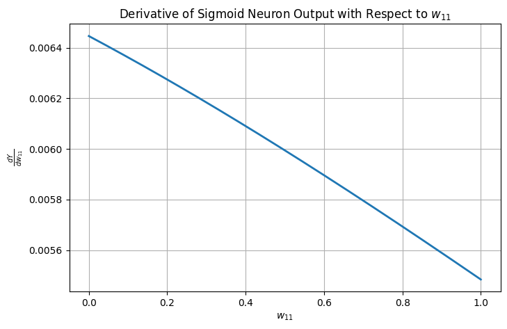

```python
np.random.seed(44)

#create a new weight marix for layer 2
layer_1_weights = np.random.rand(3, 2)

# Free w_11 input
w_11_values = np.linspace(0, 1, 300)

# Random fixed inputs: x1, x2
x1, x2 = np.random.uniform(0, 1, 2)

# Random layer 2 weights: V1, V2, V3
v1, v2, v3 = np.random.uniform(0, 1, 3)

# Random fixed Biases: b1, b2, b3 ,b4
b1, b2, b3, b4 = np.random.uniform(0, 1, 4)

#Inputs array
inputs = np.array([[x1], [x2]])

#biases array
biases_h = np.array([[b1], [b2], [b3]])

Y_values = []
dY_values = []

def sigmoid(z):
    return 1 / (1 + np.exp(-z))

for w_11 in w_11_values:
    layer_1_weights[0, 0] = w_11
    # 2 layer perceptrons

    perceptron_hiddens = sigmoid(layer_1_weights @ inputs + biases_h)
    h1, h2, h3 = perceptron_hiddens.flatten()

    # Neuron output
    Y = sigmoid(v1 * h1 + v2 * h2 + v3 * h3 + b4)
    Y_values.append(Y)

    # Derivative of Y with respect to the free input w1
    dY = x1 * h1 * (1 - h1) * v1 * Y * (1 - Y)
    dY_values.append(dY)

print(f"x1 = {x1:.4f}, x2 = {x2:.4f}")
print(f"w1_2= {layer_1_weights[0, 1]:.4f}, w2_1= {layer_1_weights[1, 0]:.4f},w2_2= {layer_1_weights[1, 1]:.4f}, w3_1= {layer_1_weights[2, 0]:.4f}, w3_2= {layer_1_weights[2, 1]:.4f}")
print(f"b1 = {b1:.4f}, b2 = {b2:.4f}, b3 = {b3:.4f}, b4 = {b4:.4f}")
print(f"h1={h1:.4f}, h2={h2:.4f}, h3={h3:.4f}")
print(f"v1 = {v1:.4f}, v2 = {v2:.4f}, v3 = {v3:.4f}")


plt.figure(figsize=(8, 5))
plt.plot(w_11_values, dY_values, linewidth=2)
plt.xlabel(r"$w_{11}$")
plt.ylabel(r"$\frac{dY}{dw_{11}}$")
plt.title(r"Derivative of Sigmoid Neuron Output with Respect to $w_{11}$")
plt.grid(True)
plt.show()
```

## Question 3:

השתמש בתוכנית פייתון שנמצאת במודל : MYFIRSTDEEPLEARNINGPROGRAM.PY ובצע את  
הסעיפים הבאים:  
א . בפונקציה train שנה את מספר ה epochs לערכים הבאים: 10 ,100 ,1000 ,10000. הצג  
את התוצאות הסופיות של כל אחת מההרצות. הסבר.  
ב . מצא את מספר ה EPOCHS האופטימלי  
ג . בפונקציה train שנה את ה learning rate לערכים הבאים: 0.5 ,0.1 ,0.05 ,0.01 ,0.005 , 0.001. הצג את התוצאות הסופיות של כל אחת מההרצות. הסבר.  
ד . מצא את ה LEARNING RATE האופטימלי.  
ה. בשורה 41 – יש משתנה bias. הצג גרף של השינוי שלו לאורך הרצת התכנית והסבר מה  
תפקידו.

## Answer 3

בתרגיל זה נשתמש בקובץ `MYFIRSTDEEPLEARNINGPROGRAM.PY`.

#### **א. שינוי מספר אפוקים**

בסעיף זה נבדוק כיצד שינוי מספר האפוקים משפיע על ביצועי המודל.

מספר אפוקים מייצג את מספר הפעמים שכל נתוני האימון עוברים דרך רשת הנוירונים. בכל אפוק מתבצע מעבר קדימה, שבו הרשת מחשבת תחזית, ולאחר מכן מתבצע עדכון של המשקולות וה־bias באמצעות Backpropagation.

כאשר מספר האפוקים נמוך מדי, נקבל בדרך כלל מצב של underfitting: המודל לא מספיק לעבור על הנתונים מספיק פעמים, ולכן המשקולות אינן מתעדכנות בצורה מספקת. כתוצאה מכך, התחזיות נשארות רחוקות מערכי המטרה והשגיאה נשארת גבוהה.

כאשר מספר האפוקים גדול יותר, למודל יש יותר הזדמנויות ללמוד את הקשר בין הקלטים לפלטים. במקרה שלנו מדובר בבעיית XOR, שהיא בעיה לא ליניארית, ולכן נדרש מספר מספיק גדול של אפוקים כדי שהרשת תצליח להתכנס לפתרון טוב.

חשוב לציין שמכיוון שהבדיקה כאן נעשית על אותם נתונים ששימשו לאימון, לא ניתן להסיק באופן מלא על overfitting. כדי לבדוק overfitting בצורה נכונה היה צורך להשתמש גם בקבוצת בדיקה נפרדת. לכן בסעיף זה נתמקד בעיקר בהשפעת מספר האפוקים על תהליך הלמידה וההתכנסות של המודל.

```python
## MYFIRSTDEEPLEARNINGPROGRAM - Neural Network Implementation

import numpy as np
import matplotlib.pyplot as plt


class SimpleNeuralNetwork:
    def __init__(self, input_size, hidden_size, output_size):
        # Random weight initialization
        self.weights_input_hidden = np.random.randn(input_size, hidden_size)
        self.bias_hidden = np.zeros((1, hidden_size))

        self.weights_hidden_output = np.random.randn(hidden_size, output_size)
        self.bias_output = np.zeros((1, output_size))

    def sigmoid(self, x):
        return 1 / (1 + np.exp(-x))

    def sigmoid_derivative(self, x):
        return x * (1 - x)

    def forward(self, X):
        # Hidden layer
        self.hidden_layer = self.sigmoid(
            np.dot(X, self.weights_input_hidden) + self.bias_hidden
        )

        # Output layer
        self.output = self.sigmoid(
            np.dot(self.hidden_layer, self.weights_hidden_output) + self.bias_output
        )

        return self.output

    def train(self, X, y, epochs=10000, learning_rate=0.1):
        for _ in range(epochs):
            # Forward propagation
            output = self.forward(X)

            # Backpropagation
            output_error = y - output
            output_delta = output_error * self.sigmoid_derivative(output)

            hidden_error = np.dot(output_delta, self.weights_hidden_output.T)
            hidden_delta = hidden_error * self.sigmoid_derivative(self.hidden_layer)

            # Weight and bias updates
            self.weights_hidden_output += learning_rate * np.dot(
                self.hidden_layer.T, output_delta
            )
            self.bias_output += learning_rate * np.sum(
                output_delta, axis=0, keepdims=True
            )

            self.weights_input_hidden += learning_rate * np.dot(X.T, hidden_delta)
            self.bias_hidden += learning_rate * np.sum(
                hidden_delta, axis=0, keepdims=True
            )

# # Example usage
# if __name__ == "__main__":
#     # XOR problem dataset
#     X = np.array([[0, 0], [0, 1], [1, 0], [1, 1]])
#     y = np.array([[0], [1], [1], [0]])

#     # Create and train neural network
#     nn = SimpleNeuralNetwork(input_size=2, hidden_size=4, output_size=1)
#     nn.train(X, y)

#     # Test predictions
#     predictions = nn.forward(X)
#     print("Predictions:\n", predictions)
#     print("\nTarget Values:\n", y)
```

```
Predictions after 10 epochs vs Target Values:
Input: [0 0] | Predicted: 0.4623 | Class: 0 | Target: 0
Input: [0 1] | Predicted: 0.4145 | Class: 0 | Target: 1
Input: [1 0] | Predicted: 0.4032 | Class: 0 | Target: 1
Input: [1 1] | Predicted: 0.3721 | Class: 0 | Target: 0
MAE after 10 epochs: 0.5042
Similarity score (1 - MAE) after 10 epochs: 0.4958
Classification accuracy after 10 epochs: 0.5000

Predictions after 100 epochs vs Target Values:
Input: [0 0] | Predicted: 0.5369 | Class: 1 | Target: 0
Input: [0 1] | Predicted: 0.5112 | Class: 1 | Target: 1
Input: [1 0] | Predicted: 0.5012 | Class: 1 | Target: 1
Input: [1 1] | Predicted: 0.4827 | Class: 0 | Target: 0
MAE after 100 epochs: 0.5018
Similarity score (1 - MAE) after 100 epochs: 0.4982
Classification accuracy after 100 epochs: 0.7500

Predictions after 1000 epochs vs Target Values:
Input: [0 0] | Predicted: 0.4749 | Class: 0 | Target: 0
Input: [0 1] | Predicted: 0.5212 | Class: 1 | Target: 1
Input: [1 0] | Predicted: 0.5012 | Class: 1 | Target: 1
Input: [1 1] | Predicted: 0.5266 | Class: 1 | Target: 0
MAE after 1000 epochs: 0.4948
Similarity score (1 - MAE) after 1000 epochs: 0.5052
Classification accuracy after 1000 epochs: 0.7500

Predictions after 10000 epochs vs Target Values:
Input: [0 0] | Predicted: 0.0373 | Class: 0 | Target: 0
Input: [0 1] | Predicted: 0.9491 | Class: 1 | Target: 1
Input: [1 0] | Predicted: 0.9448 | Class: 1 | Target: 1
Input: [1 1] | Predicted: 0.0642 | Class: 0 | Target: 0
MAE after 10000 epochs: 0.0519
Similarity score (1 - MAE) after 10000 epochs: 0.9481
Classification accuracy after 10000 epochs: 1.0000
```

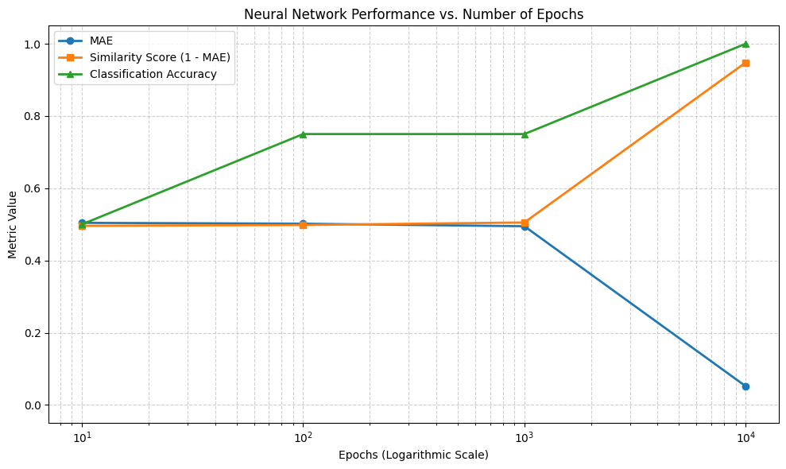

```python
# XOR problem dataset
X = np.array([
    [0, 0],
    [0, 1],
    [1, 0],
    [1, 1]
])

y = np.array([
    [0],
    [1],
    [1],
    [0]
])

EPOCHS = [10, 100, 1000, 10000]

mae_values = []
similarity_scores = []
classification_accuracies = []

for epochs in EPOCHS:
    # Same initialization for every run, so the comparison is fair
    np.random.seed(42)

    # Create and train neural network
    nn = SimpleNeuralNetwork(input_size=2, hidden_size=4, output_size=1)
    nn.train(X, y, epochs=epochs, learning_rate=0.1)

    # Test predictions
    predictions = nn.forward(X)

    # Continuous error
    mae = np.mean(np.abs(predictions - y))
    similarity_score = 1 - mae

    # Classification accuracy using threshold 0.5
    predicted_classes = (predictions >= 0.5).astype(int)
    classification_accuracy = np.mean(predicted_classes == y)

    mae_values.append(mae)
    similarity_scores.append(similarity_score)
    classification_accuracies.append(classification_accuracy)

    print(f"Predictions after {epochs} epochs vs Target Values:")
    for i in range(len(predictions)):
        print(
            f"Input: {X[i]} | "
            f"Predicted: {predictions[i][0]:.4f} | "
            f"Class: {predicted_classes[i][0]} | "
            f"Target: {y[i][0]}"
        )

    print(f"MAE after {epochs} epochs: {mae:.4f}")
    print(f"Similarity score (1 - MAE) after {epochs} epochs: {similarity_score:.4f}")
    print(f"Classification accuracy after {epochs} epochs: {classification_accuracy:.4f}\n")


# Plot error and performance metrics as a function of epochs
plt.figure(figsize=(10, 6))

plt.plot(EPOCHS, mae_values, marker='o', linewidth=2, label='MAE')
plt.plot(EPOCHS, similarity_scores, marker='s', linewidth=2, label='Similarity Score (1 - MAE)')
plt.plot(EPOCHS, classification_accuracies, marker='^', linewidth=2, label='Classification Accuracy')

plt.xscale('log')
plt.ylim(-0.05, 1.05)
plt.title('Neural Network Performance vs. Number of Epochs')
plt.xlabel('Epochs (Logarithmic Scale)')
plt.ylabel('Metric Value')
plt.legend()
plt.grid(True, which='both', linestyle='--', alpha=0.6)
plt.tight_layout()
plt.show()
```

#### **סיכום תוצאות סעיף א**

מהתוצאות ניתן לראות שמספר האפוקים משפיע בצורה משמעותית על ביצועי המודל.

בטבלה הבאה מוצגות התוצאות הסופיות שהתקבלו עבור כל מספר אפוקים:

| Epochs | MAE | Similarity Score $(1 - MAE)$ | Classification Accuracy |
| --- | --- | --- | --- |
| 10 | 0.5042 | 0.4958 | 0.50 |
| 100 | 0.5018 | 0.4982 | 0.75 |
| 1000 | 0.4948 | 0.5052 | 0.75 |
| 10000 | 0.0519 | 0.9481 | 1.00 |

עבור 10 אפוקים, המודל כמעט ואינו מצליח ללמוד את בעיית XOR. ערכי הפלט עדיין רחוקים מערכי המטרה, ולכן מתקבלת שגיאה גבוהה יחסית ודיוק סיווג נמוך.

עבור 100 ו־1000 אפוקים מתקבל שיפור מסוים בדיוק הסיווג, אך חשוב לשים לב שערכי הפלט עדיין קרובים יחסית ל־0.5. כלומר, גם כאשר חלק מהדוגמאות מסווגות נכון לפי סף החלטה של 0.5, המודל עדיין לא למד את הבעיה באופן יציב וברור.

עבור 10000 אפוקים מתקבלת ירידה משמעותית בשגיאה. הפלטים עבור הדוגמאות שהמטרה שלהן היא 0 מתקרבים ל־0, והפלטים עבור הדוגמאות שהמטרה שלהן היא 1 מתקרבים ל־1. לכן במקרה זה מתקבל גם דיוק סיווג של 100%.

חשוב להבחין בין שני מדדים שונים:

`Similarity Score = 1 - MAE` הוא מדד רציף שמראה עד כמה התחזיות קרובות לערכי המטרה.

`Classification Accuracy` הוא דיוק הסיווג בפועל לאחר שימוש בסף החלטה של 0.5.

לכן, אם הפלט הוא למשל 0.949 עבור מטרה 1, זו תחזית נכונה מבחינת סיווג, אך עדיין קיימת שגיאה מספרית קטנה כי הפלט אינו בדיוק 1.

מהגרף ניתן לראות שככל שמספר האפוקים גדל, ה־MAE יורד, בעוד שמדדי הביצוע עולים. הירידה המשמעותית ביותר בשגיאה מתקבלת בין 1000 ל־10000 אפוקים, ולכן מבין הערכים שנבדקו, 10000 אפוקים נותנים את התוצאה הטובה ביותר בסעיף זה.

המסקנה היא שמספר אפוקים קטן מדי גורם ל־underfitting, בעוד ש־10000 אפוקים מאפשרים לרשת להתכנס וללמוד בצורה טובה את הקשר הלא־ליניארי של בעיית XOR.

#### **ב. מציאת מספר אפוקים אופטימלי**

בסעיף זה נרצה למצוא את מספר האפוקים האופטימלי עבור המודל.

מכיוון שבתרגיל זה אין קבוצת בדיקה נפרדת, לא ניתן להגדיר אופטימום במובן מלא של generalization. לכן נגדיר כאן אופטימום בצורה מעשית: מספר האפוקים הקטן ביותר שבו המודל כבר פותר את בעיית XOR בצורה טובה, כלומר מתקבל דיוק סיווג של 100% וגם שגיאה ממוצעת נמוכה מספיק.

נבדוק את ביצועי הרשת עד 20,000 אפוקים, ונחשב את המדדים בכל 100 אפוקים. כדי שההשוואה תהיה הוגנת, נשתמש באותו seed אקראי כמו בסעיף הקודם, כך שהרשת תתחיל מאותה נקודת התחלה.

נגדיר את מספר האפוקים האופטימלי לפי שלושה תנאים:

1. דיוק הסיווג הוא 100%.
2. השגיאה הממוצעת נמוכה מ־5%:

$$ MAE < 0.05 $$

3. השיפור ביחס לבדיקה הקודמת קטן מ־0.001, כלומר המודל כבר נמצא באזור שבו תוספת אפוקים נותנת שיפור קטן יחסית.

בצורה זו לא נבחר בהכרח את מספר האפוקים הגדול ביותר, אלא את הנקודה שבה המודל כבר הגיע לביצועים טובים מאוד בלי להמשיך אימון מיותר.

```
--- First Epoch With 100% Classification Accuracy ---
Epoch: 3200
MAE: 0.3483

--- Practical Optimal Epochs ---
Optimal epoch: 10400
MAE: 0.0498
Similarity score (1 - MAE): 0.9502
Classification accuracy: 1.0000
Improvement from previous checkpoint: 0.000513
Predictions at optimal epoch:
Input: [0 0] | Predicted: 0.0358 | Class: 0 | Target: 0
Input: [0 1] | Predicted: 0.9513 | Class: 1 | Target: 1
Input: [1 0] | Predicted: 0.9470 | Class: 1 | Target: 1
Input: [1 1] | Predicted: 0.0616 | Class: 0 | Target: 0

--- Absolute Best Result In Checked Range ---
Epoch: 20000
MAE: 0.0273
Similarity score (1 - MAE): 0.9727
Classification accuracy: 1.0000
```

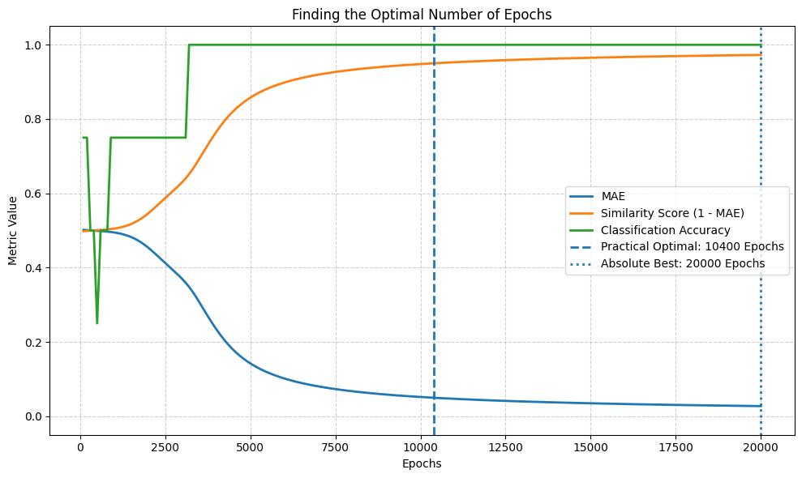

```python
def train_one_epoch(nn, X, y, learning_rate=0.1):
    output = nn.forward(X)

    output_error = y - output
    output_delta = output_error * nn.sigmoid_derivative(output)

    hidden_error = np.dot(output_delta, nn.weights_hidden_output.T)
    hidden_delta = hidden_error * nn.sigmoid_derivative(nn.hidden_layer)

    nn.weights_hidden_output += learning_rate * np.dot(nn.hidden_layer.T, output_delta)
    nn.bias_output += learning_rate * np.sum(output_delta, axis=0, keepdims=True)

    nn.weights_input_hidden += learning_rate * np.dot(X.T, hidden_delta)
    nn.bias_hidden += learning_rate * np.sum(hidden_delta, axis=0, keepdims=True)


MAX_EPOCHS = 20000
CHECK_EVERY = 100
LEARNING_RATE = 0.1

TARGET_MAE = 0.05
MIN_IMPROVEMENT = 0.001

np.random.seed(42)

nn = SimpleNeuralNetwork(input_size=2, hidden_size=4, output_size=1)

epochs_values = []
mae_values = []
similarity_scores = []
classification_accuracies = []

first_full_accuracy_epoch = None
first_full_accuracy_mae = None

optimal_epoch = None
optimal_mae = None
optimal_similarity = None
optimal_accuracy = None
optimal_predictions = None
optimal_classes = None
optimal_improvement = None

absolute_best_epoch = None
absolute_best_mae = float("inf")
absolute_best_similarity = None
absolute_best_accuracy = None
absolute_best_predictions = None

previous_mae = None

for epoch in range(1, MAX_EPOCHS + 1):
    train_one_epoch(nn, X, y, learning_rate=LEARNING_RATE)

    if epoch % CHECK_EVERY == 0:
        predictions = nn.forward(X)

        mae = np.mean(np.abs(predictions - y))
        similarity_score = 1 - mae

        predicted_classes = (predictions >= 0.5).astype(int)
        classification_accuracy = np.mean(predicted_classes == y)

        epochs_values.append(epoch)
        mae_values.append(mae)
        similarity_scores.append(similarity_score)
        classification_accuracies.append(classification_accuracy)

        if first_full_accuracy_epoch is None and classification_accuracy == 1.0:
            first_full_accuracy_epoch = epoch
            first_full_accuracy_mae = mae

        if mae < absolute_best_mae:
            absolute_best_epoch = epoch
            absolute_best_mae = mae
            absolute_best_similarity = similarity_score
            absolute_best_accuracy = classification_accuracy
            absolute_best_predictions = predictions.copy()

        if (
            optimal_epoch is None
            and classification_accuracy == 1.0
            and mae <= TARGET_MAE
            and previous_mae is not None
        ):
            improvement = previous_mae - mae

            if improvement < MIN_IMPROVEMENT:
                optimal_epoch = epoch
                optimal_mae = mae
                optimal_similarity = similarity_score
                optimal_accuracy = classification_accuracy
                optimal_predictions = predictions.copy()
                optimal_classes = predicted_classes.copy()
                optimal_improvement = improvement

        previous_mae = mae


print("--- First Epoch With 100% Classification Accuracy ---")
print(f"Epoch: {first_full_accuracy_epoch}")
print(f"MAE: {first_full_accuracy_mae:.4f}")
print()

print("--- Practical Optimal Epochs ---")
print(f"Optimal epoch: {optimal_epoch}")
print(f"MAE: {optimal_mae:.4f}")
print(f"Similarity score (1 - MAE): {optimal_similarity:.4f}")
print(f"Classification accuracy: {optimal_accuracy:.4f}")
print(f"Improvement from previous checkpoint: {optimal_improvement:.6f}")
print("Predictions at optimal epoch:")
for i in range(len(optimal_predictions)):
    print(
        f"Input: {X[i]} | "
        f"Predicted: {optimal_predictions[i][0]:.4f} | "
        f"Class: {optimal_classes[i][0]} | "
        f"Target: {y[i][0]}"
    )
print()

print("--- Absolute Best Result In Checked Range ---")
print(f"Epoch: {absolute_best_epoch}")
print(f"MAE: {absolute_best_mae:.4f}")
print(f"Similarity score (1 - MAE): {absolute_best_similarity:.4f}")
print(f"Classification accuracy: {absolute_best_accuracy:.4f}")
print()


plt.figure(figsize=(10, 6))

plt.plot(epochs_values, mae_values, linewidth=2, label='MAE')
plt.plot(epochs_values, similarity_scores, linewidth=2, label='Similarity Score (1 - MAE)')
plt.plot(epochs_values, classification_accuracies, linewidth=2, label='Classification Accuracy')

plt.axvline(
    x=optimal_epoch,
    linestyle='--',
    linewidth=2,
    label=f'Practical Optimal: {optimal_epoch} Epochs'
)

plt.axvline(
    x=absolute_best_epoch,
    linestyle=':',
    linewidth=2,
    label=f'Absolute Best: {absolute_best_epoch} Epochs'
)

plt.ylim(-0.05, 1.05)
plt.title('Finding the Optimal Number of Epochs')
plt.xlabel('Epochs')
plt.ylabel('Metric Value')
plt.legend()
plt.grid(True, linestyle='--', alpha=0.6)
plt.tight_layout()
plt.show()
```

#### **סיכום תוצאות סעיף ב**

מהבדיקה התקבל כי מספר האפוקים האופטימלי, לפי ההגדרה המעשית שבחרנו, הוא:

$$ \text{Optimal Epochs} = 10400 $$

בנקודה זו התקבלו התוצאות הבאות:

| Metric | Value |
| --- | --- |
| Optimal Epochs | 10400 |
| MAE | 0.0498 |
| Similarity Score $(1 - MAE)$ | 0.9502 |
| Classification Accuracy | 1.0000 |
| Improvement from previous checkpoint | 0.000513 |

כלומר, ב־10400 אפוקים המודל כבר מסווג נכון את כל ארבע הדוגמאות של בעיית XOR, ובמקביל השגיאה הממוצעת יורדת מתחת ל־5%.

התחזיות בנקודת האופטימום הן:

| Input | Prediction | Predicted Class | Target |
| --- | --- | --- | --- |
| $[0,0]$ | 0.0358 | 0 | 0 |
| $[0,1]$ | 0.9513 | 1 | 1 |
| $[1,0]$ | 0.9470 | 1 | 1 |
| $[1,1]$ | 0.0616 | 0 | 0 |

ניתן לראות שהפלטים עבור ערכי מטרה 0 קרובים מאוד ל־0, והפלטים עבור ערכי מטרה 1 קרובים מאוד ל־1. לכן המודל לא רק עובר את סף הסיווג של 0.5, אלא גם נותן תחזיות רציפות בטוחות יחסית.

חשוב לשים לב שהמודל הגיע לדיוק סיווג של 100% כבר ב־3200 אפוקים, אך בשלב זה ה־MAE עדיין היה גבוה יחסית:

$$ MAE = 0.3483 $$

לכן לא מספיק לבדוק רק דיוק סיווג. בבעיית XOR קטנה, ייתכן שהמודל יסווג נכון לפי סף החלטה של 0.5, אך הפלטים עדיין לא יהיו קרובים מספיק לערכי המטרה 0 ו־1.

בנוסף, התוצאה הטובה ביותר מבחינת שגיאה בלבד בטווח שנבדק התקבלה ב־20000 אפוקים:

| Metric | Value |
| --- | --- |
| Epochs | 20000 |
| MAE | 0.0273 |
| Similarity Score $(1 - MAE)$ | 0.9727 |
| Classification Accuracy | 1.0000 |

עם זאת, בחירה ב־20000 אפוקים אינה בהכרח הבחירה המעשית הטובה ביותר. אמנם השגיאה שם נמוכה יותר, אך השיפור ביחס ל־10400 אפוקים קטן יחסית, בעוד שמספר האפוקים כמעט מוכפל. לכן יש כאן trade-off בין שיפור קטן בביצועים לבין זמן אימון נוסף.

מהגרף ניתן לראות שדיוק הסיווג מגיע ל־100% מוקדם יחסית, אך ה־MAE ממשיך לרדת בהדרגה גם לאחר מכן. לכן, נקודת האופטימום המעשית אינה הנקודה הראשונה שבה מתקבל דיוק סיווג מלא, אלא הנקודה שבה מתקבלים גם דיוק מלא וגם שגיאה רציפה נמוכה מספיק.

המסקנה היא ש־10400 אפוקים הם מספר האפוקים האופטימלי באופן מעשי: בנקודה זו המודל כבר פותר את בעיית XOR בצורה מלאה, השגיאה יורדת מתחת ל־5%, והשיפור ביחס לבדיקה הקודמת קטן מאוד.

#### **ג. שינוי ערך ה־Learning Rate**

בסעיף זה נבדוק כיצד שינוי ערך ה־learning rate משפיע על ביצועי המודל.

ה־learning rate קובע את גודל הצעד שבו מתעדכנות המשקולות וה־bias בכל איטרציה של תהליך האימון. אם ערך ה־learning rate גדול מדי, העדכונים עלולים להיות חדים מדי, והרשת עלולה לדלג מעל נקודת המינימום או להתכנס בצורה לא יציבה. לעומת זאת, אם ערך ה־learning rate קטן מדי, תהליך הלמידה יהיה איטי מאוד, וייתכן שהרשת לא תספיק להגיע לפתרון טוב במסגרת מספר האפוקים שנקבע.

כדי לבודד את השפעת ה־learning rate, נשאיר את מספר האפוקים קבוע לפי התוצאה שמצאנו בסעיף ב:

$$ \text{Epochs} = 10400 $$

בנוסף, כמו בסעיפים הקודמים, נשתמש באותו seed אקראי בכל הרצה, כדי שכל הרשתות יתחילו מאותם משקלים התחלתיים. כך ניתן להשוות בצורה הוגנת בין ערכי ה־learning rate השונים.

נבדוק את הערכים הבאים:

$$ 0.5,\ 0.1,\ 0.05,\ 0.01,\ 0.005,\ 0.001 $$

```
Results for learning rate = 0.5:
Epochs: 10400
Predictions vs Target Values:
Input: [0 0] | Predicted: 0.0098 | Class: 0 | Target: 0
Input: [0 1] | Predicted: 0.9875 | Class: 1 | Target: 1
Input: [1 0] | Predicted: 0.9847 | Class: 1 | Target: 1
Input: [1 1] | Predicted: 0.0169 | Class: 0 | Target: 0
MAE: 0.0136
Similarity score (1 - MAE): 0.9864
Classification accuracy: 1.0000
----------------------------------------------------------------------
Results for learning rate = 0.1:
Epochs: 10400
Predictions vs Target Values:
Input: [0 0] | Predicted: 0.0358 | Class: 0 | Target: 0
Input: [0 1] | Predicted: 0.9513 | Class: 1 | Target: 1
Input: [1 0] | Predicted: 0.9470 | Class: 1 | Target: 1
Input: [1 1] | Predicted: 0.0616 | Class: 0 | Target: 0
MAE: 0.0498
Similarity score (1 - MAE): 0.9502
Classification accuracy: 1.0000
----------------------------------------------------------------------
Results for learning rate = 0.05:
Epochs: 10400
Predictions vs Target Values:
Input: [0 0] | Predicted: 0.0953 | Class: 0 | Target: 0
Input: [0 1] | Predicted: 0.8688 | Class: 1 | Target: 1
Input: [1 0] | Predicted: 0.8638 | Class: 1 | Target: 1
Input: [1 1] | Predicted: 0.1632 | Class: 0 | Target: 0
MAE: 0.1315
Similarity score (1 - MAE): 0.8685
Classification accuracy: 1.0000
----------------------------------------------------------------------
Results for learning rate = 0.01:
Epochs: 10400
Predictions vs Target Values:
Input: [0 0] | Predicted: 0.4722 | Class: 0 | Target: 0
Input: [0 1] | Predicted: 0.5225 | Class: 1 | Target: 1
Input: [1 0] | Predicted: 0.5016 | Class: 1 | Target: 1
Input: [1 1] | Predicted: 0.5286 | Class: 1 | Target: 0
```

[output cut: 11 more lines]

```
MAE: 0.4991
Similarity score (1 - MAE): 0.5009
Classification accuracy: 0.2500
----------------------------------------------------------------------
Results for learning rate = 0.001:
Epochs: 10400
Predictions vs Target Values:
Input: [0 0] | Predicted: 0.5365 | Class: 1 | Target: 0
Input: [0 1] | Predicted: 0.5112 | Class: 1 | Target: 1
Input: [1 0] | Predicted: 0.5012 | Class: 1 | Target: 1
Input: [1 1] | Predicted: 0.4830 | Class: 0 | Target: 0
MAE: 0.5018
Similarity score (1 - MAE): 0.4982
Classification accuracy: 0.7500
----------------------------------------------------------------------
```

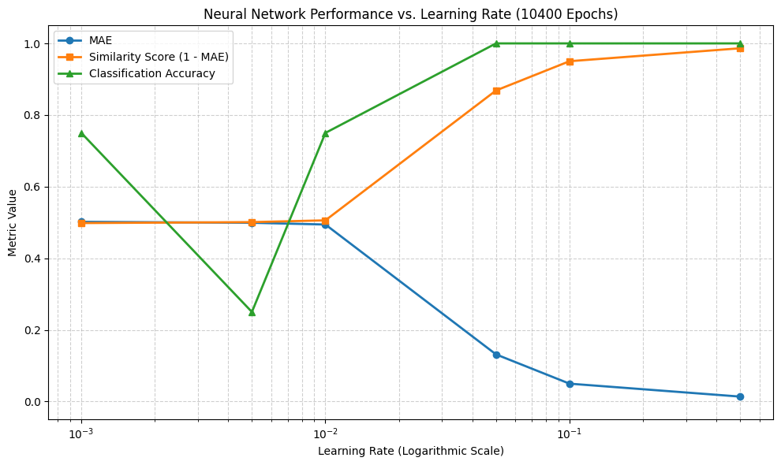

```python
LEARNING_RATES = [0.5, 0.1, 0.05, 0.01, 0.005, 0.001]
EPOCHS_FIXED = 10400

lr_results = []

mae_values_lr = []
similarity_scores_lr = []
classification_accuracies_lr = []

for learning_rate in LEARNING_RATES:
    # Same initialization for every run, so the comparison is fair
    np.random.seed(42)

    # Create and train neural network
    nn = SimpleNeuralNetwork(input_size=2, hidden_size=4, output_size=1)
    nn.train(X, y, epochs=EPOCHS_FIXED, learning_rate=learning_rate)

    # Test predictions
    predictions = nn.forward(X)

    # Continuous error
    mae = np.mean(np.abs(predictions - y))
    similarity_score = 1 - mae

    # Classification accuracy using threshold 0.5
    predicted_classes = (predictions >= 0.5).astype(int)
    classification_accuracy = np.mean(predicted_classes == y)

    mae_values_lr.append(mae)
    similarity_scores_lr.append(similarity_score)
    classification_accuracies_lr.append(classification_accuracy)

    lr_results.append({
        "learning_rate": learning_rate,
        "mae": mae,
        "similarity_score": similarity_score,
        "classification_accuracy": classification_accuracy,
        "predictions": predictions.copy(),
        "predicted_classes": predicted_classes.copy()
    })

    print(f"Results for learning rate = {learning_rate}:")
    print(f"Epochs: {EPOCHS_FIXED}")
    print("Predictions vs Target Values:")
    for i in range(len(predictions)):
        print(
            f"Input: {X[i]} | "
            f"Predicted: {predictions[i][0]:.4f} | "
            f"Class: {predicted_classes[i][0]} | "
            f"Target: {y[i][0]}"
        )

    print(f"MAE: {mae:.4f}")
    print(f"Similarity score (1 - MAE): {similarity_score:.4f}")
    print(f"Classification accuracy: {classification_accuracy:.4f}")
    print("-" * 70)


# Plot metrics as a function of learning rate
# Sort learning rates for a clearer logarithmic plot
sorted_results = sorted(lr_results, key=lambda item: item["learning_rate"])

sorted_learning_rates = [item["learning_rate"] for item in sorted_results]
sorted_mae_values = [item["mae"] for item in sorted_results]
sorted_similarity_scores = [item["similarity_score"] for item in sorted_results]
sorted_classification_accuracies = [item["classification_accuracy"] for item in sorted_results]

plt.figure(figsize=(10, 6))

plt.plot(sorted_learning_rates, sorted_mae_values, marker='o', linewidth=2, label='MAE')
plt.plot(sorted_learning_rates, sorted_similarity_scores, marker='s', linewidth=2, label='Similarity Score (1 - MAE)')
plt.plot(sorted_learning_rates, sorted_classification_accuracies, marker='^', linewidth=2, label='Classification Accuracy')

plt.xscale('log')
plt.ylim(-0.05, 1.05)
plt.title(f'Neural Network Performance vs. Learning Rate ({EPOCHS_FIXED} Epochs)')
plt.xlabel('Learning Rate (Logarithmic Scale)')
plt.ylabel('Metric Value')
plt.legend()
plt.grid(True, which='both', linestyle='--', alpha=0.6)
plt.tight_layout()
plt.show()
```

#### **סיכום תוצאות סעיף ג**

מהתוצאות ניתן לראות שערך ה־learning rate משפיע בצורה משמעותית על איכות הלמידה של המודל.

בטבלה הבאה מוצגות התוצאות הסופיות שהתקבלו עבור כל ערך של learning rate, כאשר מספר האפוקים נשאר קבוע:

$$ \text{Epochs} = 10400 $$

| Learning Rate | MAE | Similarity Score $(1 - MAE)$ | Classification Accuracy |
| --- | --- | --- | --- |
| 0.5 | 0.0136 | 0.9864 | 1.0000 |
| 0.1 | 0.0498 | 0.9502 | 1.0000 |
| 0.05 | 0.1315 | 0.8685 | 1.0000 |
| 0.01 | 0.4942 | 0.5058 | 0.7500 |
| 0.005 | 0.4991 | 0.5009 | 0.2500 |
| 0.001 | 0.5018 | 0.4982 | 0.7500 |

עבור ערכי learning rate קטנים מאוד, כמו 0.001 ו־0.005, המודל כמעט ואינו מצליח להתכנס במסגרת 10400 אפוקים. הפלטים נשארים קרובים מאוד ל־0.5, ולכן הרשת עדיין לא למדה בצורה טובה את בעיית XOR. במצב כזה קצב העדכון של המשקולות קטן מדי, ולכן גם לאחר מספר גדול יחסית של אפוקים, השגיאה נשארת גבוהה.

עבור learning rate = 0.01 מתקבל שיפור קל בלבד. דיוק הסיווג הוא 75%, אך ה־MAE עדיין גבוה מאוד, ולכן המודל עדיין אינו פותר את הבעיה בצורה טובה. כלומר, חלק מהתחזיות עוברות את סף הסיווג הנכון, אך הפלטים עצמם עדיין לא קרובים מספיק לערכי המטרה.

עבור learning rate = 0.05 מתקבל כבר דיוק סיווג של 100%, אך השגיאה הממוצעת עדיין יחסית גבוהה:

$$ MAE = 0.1315 $$

כלומר, המודל מסווג נכון את כל הדוגמאות, אך התחזיות הרציפות עדיין אינן קרובות מאוד ל־0 ול־1. לדוגמה, עבור קלטים שהמטרה שלהם היא 1 התקבלו תחזיות באזור 0.86, ועבור קלטים שהמטרה שלהם היא 0 התקבלו ערכים באזור 0.09 ו־0.16.

עבור learning rate = 0.1 מתקבלת תוצאה טובה יותר. המודל מגיע לדיוק סיווג של 100%, וגם ה־MAE יורד מתחת ל־5%:

$$ MAE = 0.0498 $$

עבור learning rate = 0.5 התקבלה התוצאה הטובה ביותר מבין הערכים שנבדקו. השגיאה הממוצעת היא הנמוכה ביותר:

$$ MAE = 0.0136 $$

והתחזיות קרובות מאוד לערכי המטרה:

| Input | Prediction | Predicted Class | Target |
| --- | --- | --- | --- |
| $[0,0]$ | 0.0098 | 0 | 0 |
| $[0,1]$ | 0.9875 | 1 | 1 |
| $[1,0]$ | 0.9847 | 1 | 1 |
| $[1,1]$ | 0.0169 | 0 | 0 |

המסקנה מסעיף זה היא שערכי learning rate קטנים מדי גורמים ללמידה איטית מאוד ול־underfitting במסגרת מספר האפוקים שנבחר. לעומת זאת, learning rate = 0.5 נתן את הביצועים הטובים ביותר מבין הערכים שנבדקו, עם דיוק סיווג מלא ושגיאה ממוצעת נמוכה מאוד.

#### **ד. מציאת ערך ה־Learning Rate האופטימלי**

בסעיף הקודם בדקנו מספר ערכי learning rate קבועים, וראינו שלערך ה־learning rate יש השפעה משמעותית על יכולת ההתכנסות של המודל.

בסעיף זה נרצה למצוא את ערך ה־learning rate האופטימלי בצורה מדויקת יותר. לשם כך נבדוק טווח רחב יותר של ערכי learning rate, ולא רק את הערכים שניתנו בסעיף ג.

נשאיר את מספר האפוקים קבוע לפי התוצאה שנמצאה בסעיף ב:

$$ \text{Epochs} = 10400 $$

כדי לבצע השוואה הוגנת, בכל הרצה נאפס את ה־seed האקראי לאותו ערך. כך כל רשת תתחיל מאותם משקלים התחלתיים, וההבדל בתוצאות ינבע מערך ה־learning rate בלבד.

נגדיר את ה־learning rate האופטימלי כערך שמקיים את שני התנאים הבאים:

1. דיוק הסיווג הוא 100%.
2. ערך ה־MAE הוא הנמוך ביותר מבין הערכים שנבדקו.

כלומר, נבחר את ערך ה־learning rate שמוביל גם לסיווג נכון של כל דוגמאות XOR וגם לשגיאה הרציפה הקטנה ביותר.

```
--- Optimal Learning Rate Search ---
Fixed epochs: 10400
Best learning rate: 1.000000
MAE: 0.0088
Similarity score (1 - MAE): 0.9912
Classification accuracy: 1.0000

Predictions at optimal learning rate:
Input: [0 0] | Predicted: 0.0063 | Class: 0 | Target: 0
Input: [0 1] | Predicted: 0.9920 | Class: 1 | Target: 1
Input: [1 0] | Predicted: 0.9901 | Class: 1 | Target: 1
Input: [1 1] | Predicted: 0.0109 | Class: 0 | Target: 0
```

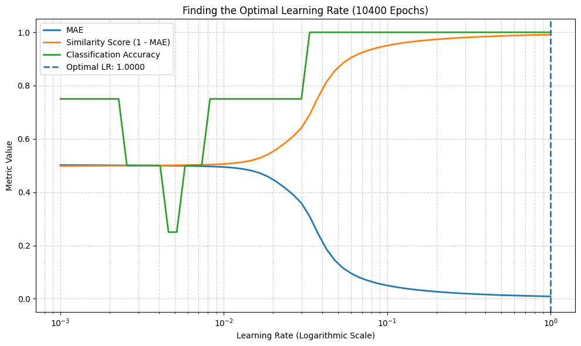

```
--- Top 10 Learning Rates By MAE ---
Learning Rate | MAE | Similarity Score | Classification Accuracy
----------------------------------------------------------------------
1.000000 | 0.0088 | 0.9912 | 1.0000
0.889513 | 0.0094 | 0.9906 | 1.0000
0.791234 | 0.0101 | 0.9899 | 1.0000
0.703814 | 0.0109 | 0.9891 | 1.0000
0.626052 | 0.0118 | 0.9882 | 1.0000
0.556881 | 0.0127 | 0.9873 | 1.0000
0.495354 | 0.0137 | 0.9863 | 1.0000
0.440624 | 0.0148 | 0.9852 | 1.0000
0.391941 | 0.0161 | 0.9839 | 1.0000
0.348637 | 0.0175 | 0.9825 | 1.0000
```

```python
# Search for the optimal learning rate

EPOCHS_FIXED = 10400

# We search over a wider range than part C.
# Logarithmic spacing is useful because learning rate effects are multiplicative.
learning_rates_search = np.logspace(-3, 0, 60)  # From 0.001 to 1.0

search_results = []

best_lr = None
best_mae = float("inf")
best_similarity = None
best_accuracy = None
best_predictions = None
best_classes = None

for learning_rate in learning_rates_search:
    # Same initialization for every run, so the comparison is fair
    np.random.seed(42)

    nn = SimpleNeuralNetwork(input_size=2, hidden_size=4, output_size=1)
    nn.train(X, y, epochs=EPOCHS_FIXED, learning_rate=learning_rate)

    predictions = nn.forward(X)

    mae = np.mean(np.abs(predictions - y))
    similarity_score = 1 - mae

    predicted_classes = (predictions >= 0.5).astype(int)
    classification_accuracy = np.mean(predicted_classes == y)

    search_results.append({
        "learning_rate": learning_rate,
        "mae": mae,
        "similarity_score": similarity_score,
        "classification_accuracy": classification_accuracy,
        "predictions": predictions.copy(),
        "predicted_classes": predicted_classes.copy()
    })

    # Select the best learning rate among models that classify all examples correctly
    if classification_accuracy == 1.0 and mae < best_mae:
        best_lr = learning_rate
        best_mae = mae
        best_similarity = similarity_score
        best_accuracy = classification_accuracy
        best_predictions = predictions.copy()
        best_classes = predicted_classes.copy()


print("--- Optimal Learning Rate Search ---")
print(f"Fixed epochs: {EPOCHS_FIXED}")
print(f"Best learning rate: {best_lr:.6f}")
print(f"MAE: {best_mae:.4f}")
print(f"Similarity score (1 - MAE): {best_similarity:.4f}")
print(f"Classification accuracy: {best_accuracy:.4f}")
print()
print("Predictions at optimal learning rate:")
for i in range(len(best_predictions)):
    print(
        f"Input: {X[i]} | "
        f"Predicted: {best_predictions[i][0]:.4f} | "
        f"Class: {best_classes[i][0]} | "
        f"Target: {y[i][0]}"
    )


# Extract values for plotting
learning_rates_plot = [item["learning_rate"] for item in search_results]
mae_plot = [item["mae"] for item in search_results]
similarity_plot = [item["similarity_score"] for item in search_results]
accuracy_plot = [item["classification_accuracy"] for item in search_results]

plt.figure(figsize=(10, 6))

plt.plot(learning_rates_plot, mae_plot, linewidth=2, label='MAE')
plt.plot(learning_rates_plot, similarity_plot, linewidth=2, label='Similarity Score (1 - MAE)')
plt.plot(learning_rates_plot, accuracy_plot, linewidth=2, label='Classification Accuracy')

plt.axvline(
    x=best_lr,
    linestyle='--',
    linewidth=2,
    label=f'Optimal LR: {best_lr:.4f}'
)

plt.xscale('log')
plt.ylim(-0.05, 1.05)
plt.title(f'Finding the Optimal Learning Rate ({EPOCHS_FIXED} Epochs)')
plt.xlabel('Learning Rate (Logarithmic Scale)')
plt.ylabel('Metric Value')
plt.legend()
plt.grid(True, which='both', linestyle='--', alpha=0.6)
plt.tight_layout()
plt.show()


# Print a compact table of the best few results
sorted_by_mae = sorted(search_results, key=lambda item: item["mae"])

print("\n--- Top 10 Learning Rates By MAE ---")
print("Learning Rate | MAE | Similarity Score | Classification Accuracy")
print("-" * 70)

for item in sorted_by_mae[:10]:
    print(
        f"{item['learning_rate']:.6f} | "
        f"{item['mae']:.4f} | "
        f"{item['similarity_score']:.4f} | "
        f"{item['classification_accuracy']:.4f}"
    )
```

#### **סיכום תוצאות סעיף ד**

מהבדיקה התקבל כי ערך ה־learning rate האופטימלי בטווח שנבדק הוא:

$$ \text{Optimal Learning Rate} = 1.0 $$

בנקודה זו התקבלו התוצאות הבאות:

| Metric | Value |
| --- | --- |
| Learning Rate | 1.0000 |
| Epochs | 10400 |
| MAE | 0.0088 |
| Similarity Score $(1 - MAE)$ | 0.9912 |
| Classification Accuracy | 1.0000 |

התחזיות שהתקבלו עבור ערך זה הן:

| Input | Prediction | Predicted Class | Target |
| --- | --- | --- | --- |
| $[0,0]$ | 0.0063 | 0 | 0 |
| $[0,1]$ | 0.9920 | 1 | 1 |
| $[1,0]$ | 0.9901 | 1 | 1 |
| $[1,1]$ | 0.0109 | 0 | 0 |

ניתן לראות שהמודל מסווג נכון את כל ארבע הדוגמאות של בעיית XOR, ובנוסף התחזיות הרציפות קרובות מאוד לערכי המטרה. עבור דוגמאות שהמטרה שלהן היא 0, הפלטים קרובים מאוד ל־0. עבור דוגמאות שהמטרה שלהן היא 1, הפלטים קרובים מאוד ל־1.

בהשוואה לסעיף ג, שבו הערך הגבוה ביותר שנבדק היה:

$$ \text{Learning Rate} = 0.5 $$

קיבלנו עבורו:

$$ MAE = 0.0136 $$

ואילו עבור:

$$ \text{Learning Rate} = 1.0 $$

קיבלנו:

$$ MAE = 0.0088 $$

כלומר, הגדלת ה־learning rate מ־0.5 ל־1.0 שיפרה את איכות התחזיות והקטינה את השגיאה.

מהגרף ניתן לראות שבערכים נמוכים של learning rate, המודל מתקשה להתכנס במסגרת 10400 אפוקים. ה־MAE נשאר גבוה יחסית, והפלטים קרובים מדי ל־0.5. כאשר ה־learning rate גדל, קצב הלמידה משתפר, ה־MAE יורד, וה־Similarity Score עולה.

חשוב לציין שהאופטימום שמצאנו הוא האופטימום בתוך הטווח שנבדק:

$$ 0.001 \leq \text{Learning Rate} \leq 1.0 $$

מכיוון שהערך האופטימלי נמצא בקצה העליון של הטווח, ייתכן שבדיקה של ערכים גדולים יותר הייתה מראה האם ניתן לשפר עוד את התוצאה או האם המודל מתחיל להיות לא יציב. עם זאת, לפי הטווח שנבדק בתרגיל, הערך:

$$ \text{Learning Rate} = 1.0 $$

הוא הערך האופטימלי, משום שהוא נותן את השגיאה הנמוכה ביותר יחד עם דיוק סיווג מלא של 100%.

#### **ה. גרף שינוי ה־bias לאורך האימון**

בסעיף זה נבדוק את השינוי בערכי ה־bias לאורך תהליך האימון של הרשת.

במודל הנתון קיימים שני סוגים של bias:

1. `bias_hidden` - ערכי bias של שכבת ה־hidden layer.
2. `bias_output` - ערך bias של שכבת הפלט.

תפקיד ה־bias הוא לאפשר לכל נוירון להזיז את פונקציית ההפעלה שלו ימינה או שמאלה, ולא להיות תלוי רק במשקולות ובקלטים. ללא bias, הפלט של כל נוירון היה תלוי רק בצירוף הליניארי של הקלטים והמשקולות, ולכן יכולת ההתאמה של הרשת הייתה מוגבלת יותר.

במילים אחרות, ה־bias מוסיף לרשת גמישות. הוא מאפשר לרשת ללמוד קשרים שאינם עוברים בהכרח דרך ראשית הצירים, ולכן הוא חשוב במיוחד בבעיות לא ליניאריות כמו XOR.

בסעיף זה נריץ את האימון פעם אחת, תוך שמירה של ערכי ה־bias לאחר כל אפוק. לאחר מכן נציג גרף של השינוי בערכי ה־bias לאורך האימון.

נשתמש בערכים האופטימליים שמצאנו בסעיפים הקודמים:

$$ \text{Epochs} = 10400 $$

$$ \text{Learning Rate} = 1.0 $$

```
--- Bias Tracking Results ---
Epochs: 10400
Learning rate: 1.0
Final MAE: 0.0088
Final classification accuracy: 1.0000

Final bias_output:
[[-1.42623823]]

Final bias_hidden:
[[ 1.86144242 -0.24714274 -3.65240795 -2.31163772]]

Final predictions:
Input: [0 0] | Predicted: 0.0063 | Class: 0 | Target: 0
Input: [0 1] | Predicted: 0.9920 | Class: 1 | Target: 1
Input: [1 0] | Predicted: 0.9901 | Class: 1 | Target: 1
Input: [1 1] | Predicted: 0.0109 | Class: 0 | Target: 0
```

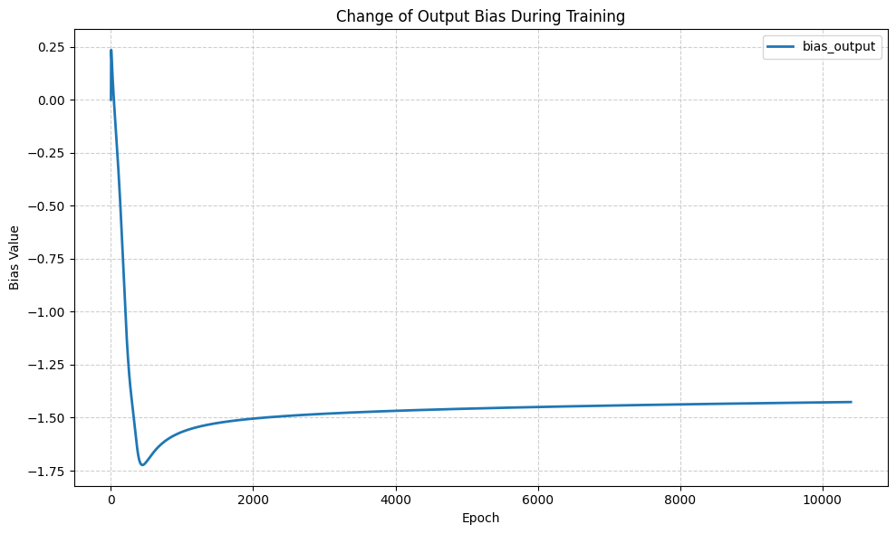

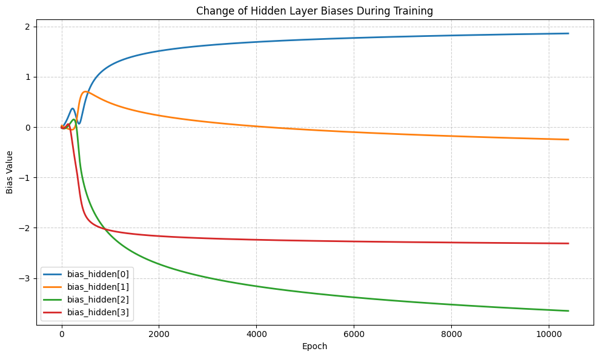

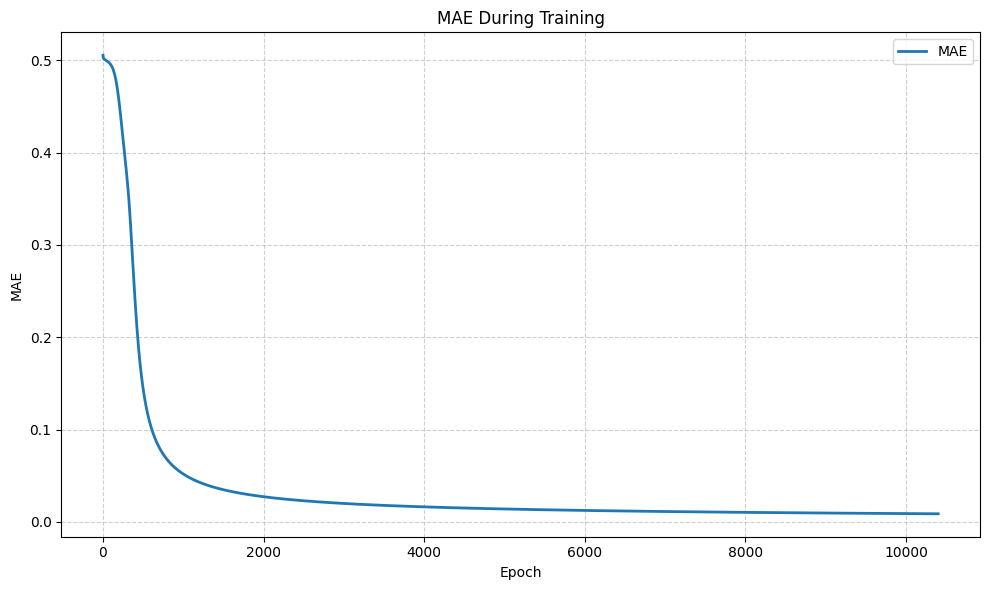

```python
def train_with_bias_tracking(nn, X, y, epochs=10400, learning_rate=1.0):
    bias_hidden_history = []
    bias_output_history = []
    mae_history = []

    for _ in range(epochs):
        # Forward propagation
        output = nn.forward(X)

        # Calculate MAE for tracking model improvement
        mae = np.mean(np.abs(output - y))
        mae_history.append(mae)

        # Save current bias values
        bias_hidden_history.append(nn.bias_hidden.flatten().copy())
        bias_output_history.append(nn.bias_output[0, 0].copy())

        # Backpropagation
        output_error = y - output
        output_delta = output_error * nn.sigmoid_derivative(output)

        hidden_error = np.dot(output_delta, nn.weights_hidden_output.T)
        hidden_delta = hidden_error * nn.sigmoid_derivative(nn.hidden_layer)

        # Weight and bias updates
        nn.weights_hidden_output += learning_rate * np.dot(nn.hidden_layer.T, output_delta)
        nn.bias_output += learning_rate * np.sum(output_delta, axis=0, keepdims=True)

        nn.weights_input_hidden += learning_rate * np.dot(X.T, hidden_delta)
        nn.bias_hidden += learning_rate * np.sum(hidden_delta, axis=0, keepdims=True)

    return (
        np.array(bias_hidden_history),
        np.array(bias_output_history),
        np.array(mae_history)
    )


EPOCHS_BIAS = 10400
LEARNING_RATE_BIAS = 1.0

np.random.seed(42)

nn = SimpleNeuralNetwork(input_size=2, hidden_size=4, output_size=1)

bias_hidden_history, bias_output_history, mae_history = train_with_bias_tracking(
    nn,
    X,
    y,
    epochs=EPOCHS_BIAS,
    learning_rate=LEARNING_RATE_BIAS
)

final_predictions = nn.forward(X)
final_classes = (final_predictions >= 0.5).astype(int)
final_mae = np.mean(np.abs(final_predictions - y))
final_accuracy = np.mean(final_classes == y)

print("--- Bias Tracking Results ---")
print(f"Epochs: {EPOCHS_BIAS}")
print(f"Learning rate: {LEARNING_RATE_BIAS}")
print(f"Final MAE: {final_mae:.4f}")
print(f"Final classification accuracy: {final_accuracy:.4f}")
print()

print("Final bias_output:")
print(nn.bias_output)
print()

print("Final bias_hidden:")
print(nn.bias_hidden)
print()

print("Final predictions:")
for i in range(len(final_predictions)):
    print(
        f"Input: {X[i]} | "
        f"Predicted: {final_predictions[i][0]:.4f} | "
        f"Class: {final_classes[i][0]} | "
        f"Target: {y[i][0]}"
    )


epochs_axis = np.arange(1, EPOCHS_BIAS + 1)

# Plot output bias
plt.figure(figsize=(10, 6))
plt.plot(epochs_axis, bias_output_history, linewidth=2, label='bias_output')

plt.title('Change of Output Bias During Training')
plt.xlabel('Epoch')
plt.ylabel('Bias Value')
plt.legend()
plt.grid(True, linestyle='--', alpha=0.6)
plt.tight_layout()
plt.show()


# Plot hidden layer biases
plt.figure(figsize=(10, 6))

for i in range(bias_hidden_history.shape[1]):
    plt.plot(
        epochs_axis,
        bias_hidden_history[:, i],
        linewidth=2,
        label=f'bias_hidden[{i}]'
    )

plt.title('Change of Hidden Layer Biases During Training')
plt.xlabel('Epoch')
plt.ylabel('Bias Value')
plt.legend()
plt.grid(True, linestyle='--', alpha=0.6)
plt.tight_layout()
plt.show()


# Plot MAE to compare bias changes with model convergence
plt.figure(figsize=(10, 6))
plt.plot(epochs_axis, mae_history, linewidth=2, label='MAE')

plt.title('MAE During Training')
plt.xlabel('Epoch')
plt.ylabel('MAE')
plt.legend()
plt.grid(True, linestyle='--', alpha=0.6)
plt.tight_layout()
plt.show()
```

#### **סיכום תוצאות סעיף ה**

בסעיף זה עקבנו אחרי ערכי ה־bias לאורך תהליך האימון של הרשת.

במודל קיימים שני סוגים של bias:

| Bias | Description |
| --- | --- |
| `bias_hidden` | ערכי ה־bias של ארבעת הנוירונים בשכבת ה־hidden layer |
| `bias_output` | ערך ה־bias של נוירון הפלט |

בסוף האימון התקבלו הערכים הבאים:

| Parameter | Final Value |
| --- | --- |
| `bias_output` | -1.4262 |
| `bias_hidden[0]` | 1.8614 |
| `bias_hidden[1]` | -0.2471 |
| `bias_hidden[2]` | -3.6524 |
| `bias_hidden[3]` | -2.3116 |

בנוסף, בסוף האימון התקבלו ביצועי מודל טובים מאוד:

| Metric | Value |
| --- | --- |
| Epochs | 10400 |
| Learning Rate | 1.0 |
| Final MAE | 0.0088 |
| Classification Accuracy | 1.0000 |

התחזיות הסופיות של המודל הן:

| Input | Prediction | Predicted Class | Target |
| --- | --- | --- | --- |
| $[0,0]$ | 0.0063 | 0 | 0 |
| $[0,1]$ | 0.9920 | 1 | 1 |
| $[1,0]$ | 0.9901 | 1 | 1 |
| $[1,1]$ | 0.0109 | 0 | 0 |

מהגרף של `bias_output` ניתן לראות שבהתחלה ערך ה־bias משתנה בצורה חדה מאוד. הוא יורד במהירות לערך שלילי נמוך, ולאחר מכן מתייצב בהדרגה סביב הערך הסופי:

$$ bias Output \approx -1.4262 $$

משמעות הדבר היא שבשלבים הראשונים של האימון הרשת משנה במהירות את נקודת העבודה של נוירון הפלט. לאחר שהמודל מתחיל להתקרב לפתרון טוב יותר, השינויים ב־bias הופכים קטנים יותר, והערך מתכנס בהדרגה.

מהגרף של `bias_hidden` ניתן לראות שכל אחד מארבעת הנוירונים בשכבה החבויה לומד ערך bias שונה. חלק מהערכים נעשים חיוביים וחלק נעשים שליליים. לדוגמה, `bias_hidden[0]` עולה לערך חיובי, בעוד ש־`bias_hidden[2]` ו־`bias_hidden[3]` יורדים לערכים שליליים יחסית גדולים.

תוצאה זו הגיונית, משום שכל נוירון בשכבת ה־hidden layer לומד תפקיד שונה בייצוג הפנימי של בעיית XOR. מכיוון שבעיית XOR אינה ניתנת להפרדה ליניארית על ידי קו ישר אחד, הרשת צריכה להשתמש בכמה נוירונים חבויים, שכל אחד מהם יוצר גבול החלטה שונה. ערכי ה־bias מאפשרים להזיז את גבולות ההחלטה האלה ולאלץ את פונקציית הסיגמואיד לפעול באזורים שונים של מרחב הקלט.

הגרף השלישי, של ה־MAE לאורך האימון, מראה שבמקביל לשינוי בערכי ה־bias, השגיאה יורדת בצורה חדה בתחילת האימון ולאחר מכן ממשיכה לרדת בצורה מתונה יותר. כלומר, השינויים ב־bias אינם מקריים: הם חלק מתהליך ההתכנסות של המודל לפתרון נכון של בעיית XOR.

תפקיד ה־bias הוא להוסיף לכל נוירון פרמטר חופשי שאינו תלוי ישירות בערכי הקלט. מבחינה מתמטית, במקום לחשב רק:

$$ z = w_1x_1 + w_2x_2 $$

הנוירון מחשב:

$$ z = w_1x_1 + w_2x_2 + b $$

כאשר $b$ הוא ה־bias. לכן ה־bias מאפשר להזיז את פונקציית ההפעלה ימינה או שמאלה, ולא מגביל את המודל למעברים שמתרחשים רק סביב ראשית הצירים.

המסקנה היא שה־bias הוא חלק מרכזי ביכולת הלמידה של הרשת. הוא מאפשר לרשת להתאים את גבולות ההחלטה שלה בצורה גמישה יותר, ובמקרה של בעיית XOR הוא מסייע לרשת ללמוד קשר לא ליניארי בצורה מוצלחת.

## Question 4

בהתייחס לרשת המופיעה בשאלה 2:

א. תאר בעיית קלאסיפיקציה שיכולה להתאים לרשת זו.

ב. תאר בעיית רגרסיה שיכולה להתאים לרשת זו.

ג. סנתז דאטאסט קטן, 50-100 שורות, המתאים לבעיית הקלאסיפיקציה והצג עבורו את תהליך ההתכנסות לאורך ה־EPOCHS, כלומר שינוי ב־LOSS וב־ACCURACY.

ד. שנה את הדאטאסט שיצרת בסעיף ג' כך שתהליך ההתכנסות ישתפר. הסבר את השינוי.

ה. שנה את הדאטאסט שיצרת בסעיף ג' כך שתהליך ההתכנסות יהיה איטי יותר באופן משמעותי. הסבר את השינוי.

## Answer 4

בשאלה זו נתייחס לרשת שהופיעה בשאלה 2.

הרשת מקבלת שני קלטים:

$$ x_1,\ x_2 $$

יש לה שכבה נסתרת עם שלושה נוירונים:

$$ h_1,\ h_2,\ h_3 $$

ושכבת פלט עם נוירון יחיד:

$$ Y $$

פונקציית האקטיבציה היא סיגמואיד, ולכן הפלט של הרשת נמצא בתחום:

$$ 0 < Y < 1 $$

מבנה כזה מתאים גם לבעיות קלאסיפיקציה בינארית, שבהן מפרשים את הפלט כהסתברות למחלקה 1, וגם לבעיות רגרסיה שבהן רוצים לחזות ערך רציף בתחום $[0,1]$.

#### **א. בעיית קלאסיפיקציה המתאימה לרשת**

בעיה מתאימה לרשת זו היא בעיית קלאסיפיקציה בינארית עם שני מאפיינים מספריים.

לדוגמה, נניח שיש לנו מערכת שמקבלת שני מדדים מחיישנים:

$$ x_1 = \text{רמת רעש} $$

$$ x_2 = \text{רמת רעידות} $$

המטרה היא לסווג האם מכונה נמצאת במצב תקין או במצב חריג:

$$ Y = \begin{cases} 0, & \text{מצב תקין} \\ 1, & \text{מצב חריג} \end{cases} $$

כלומר, הרשת מקבלת שני קלטים מספריים, מעבירה אותם דרך שלושה נוירונים בשכבה הנסתרת, ומחזירה פלט יחיד בין 0 ל־1. במקרה של קלאסיפיקציה, נפרש את הפלט כהסתברות:

$$ Y = P(\text{class}=1 \mid x_1,x_2) $$

ולכן ניתן להשתמש בסף החלטה של 0.5:

$$ \hat{y} = \begin{cases} 1, & Y \geq 0.5 \\ 0, & Y < 0.5 \end{cases} $$

רשת זו מתאימה לבעיה כזו משום שיש לה שני קלטים, פלט יחיד, ופונקציית סיגמואיד בפלט שמאפשרת לפרש את התוצאה כהסתברות למחלקה חיובית.

#### **ב. בעיית רגרסיה המתאימה לרשת**

בעיה מתאימה נוספת היא בעיית רגרסיה שבה רוצים לחזות ערך רציף בתחום $[0,1]$ על סמך שני קלטים.

לדוגמה, נניח שאנו רוצים לחזות את רמת הסיכון של מכונה לתקלה בזמן הקרוב, לפי שני מדדים:

$$ x_1 = \text{רמת רעש} $$

$$ x_2 = \text{רמת רעידות} $$

במקום לסווג את המכונה רק ל־תקינה או חריגה, נרצה להחזיר ערך רציף:

$$ Y \in [0,1] $$

כאשר:

- ערך קרוב ל־0 מציין סיכון נמוך לתקלה.
- ערך קרוב ל־1 מציין סיכון גבוה לתקלה.

לדוגמה:

$$ Y = 0.15 $$

יכול לציין סיכון נמוך, ואילו:

$$ Y = 0.87 $$

יכול לציין סיכון גבוה.

במקרה כזה הפלט של הרשת אינו מתורגם למחלקה בעזרת סף, אלא נשאר ערך רציף. מכיוון שפונקציית הסיגמואיד מחזירה ערכים בתחום $[0,1]$, היא מתאימה במיוחד לרגרסיה שבה ערך היעד מנורמל לטווח זה.

#### **ג. סינתוז דאטאסט קטן והצגת תהליך ההתכנסות**

בסעיף זה ניצור דאטאסט סינתטי קטן עבור בעיית הקלאסיפיקציה שתוארה בסעיף א.

הדאטאסט יכלול 80 דוגמאות, כלומר מספר שורות שנמצא בטווח המבוקש של 50-100 שורות. לכל דוגמה יהיו שני מאפיינים:

$$ x_1,\ x_2 $$

והתווית תהיה בינארית:

$$ y \in {0,1} $$

נבנה את הדאטאסט כך שמחלקה 0 ומחלקה 1 יהיו שונות זו מזו, אך לא באופן מושלם. כלומר, תהיה חפיפה מסוימת בין המחלקות, כדי שתהליך הלמידה לא יהיה טריוויאלי מדי.

נשתמש ברשת מהשאלה:

$$ 2 \rightarrow 3 \rightarrow 1 $$

כלומר שני קלטים, שלושה נוירונים בשכבה הנסתרת, ופלט יחיד.

לאורך האימון נעקוב אחרי שני מדדים:

1. פונקציית הפסד מסוג Binary Cross Entropy:

$$ Loss = -\frac{1}{n}\sum_{i=1}^{n} \left[ y_i\log(\hat{y}_i) + (1-y_i)\log(1-\hat{y}_i) \right] $$

2. דיוק הסיווג

$$ Accuracy = \frac{\text{Number of correct predictions}}{\text{Total number of predictions}} $$

לבסוף נציג גרף שמראה את שינוי ה־Loss וה־Accuracy לאורך האפוקים.

```
Synthetic dataset shape: (80, 3)

First 10 rows of the dataset:
```

|  | x1_noise_level | x2_vibration_level | target |
| --- | --- | --- | --- |
| 0 | 0.429474 | 0.327878 | 0.0 |
| 1 | 0.453630 | 0.593685 | 0.0 |
| 2 | 0.312535 | 0.312538 | 0.0 |
| 3 | 0.602674 | 0.472790 | 0.0 |
| 4 | 0.274884 | 0.436810 | 0.0 |
| 5 | 0.275853 | 0.275483 | 0.0 |
| 6 | 0.388714 | 0.043875 | 0.0 |
| 7 | 0.074013 | 0.260034 | 0.0 |
| 8 | 0.187947 | 0.400280 | 0.0 |
| 9 | 0.204716 | 0.124031 | 0.0 |

```
Class distribution:
target
0.0    40
1.0    40
Name: count, dtype: int64
```

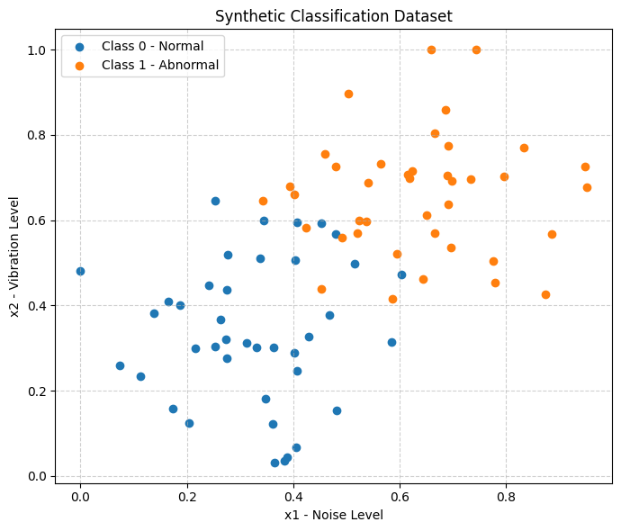

```
--- Training Results For Part C ---
Epochs: 3000
Learning rate: 1.0
Final loss: 0.1531
Final accuracy: 0.9125

First 10 predictions:
x = [0.42947426 0.32787771] | prediction = 0.0182 | class = 0 | target = 0
x = [0.45363017 0.59368478] | prediction = 0.6889 | class = 1 | target = 0
x = [0.31253546 0.31253809] | prediction = 0.0038 | class = 0 | target = 0
x = [0.60267405 0.47278956] | prediction = 0.7435 | class = 1 | target = 0
x = [0.2748841  0.43680961] | prediction = 0.0094 | class = 0 | target = 0
x = [0.27585317 0.27548324] | prediction = 0.0019 | class = 0 | target = 0
x = [0.38871396 0.04387516] | prediction = 0.0009 | class = 0 | target = 0
x = [0.07401315 0.260034  ] | prediction = 0.0003 | class = 0 | target = 0
x = [0.18794702 0.40027957] | prediction = 0.0023 | class = 0 | target = 0
x = [0.20471615 0.12403141] | prediction = 0.0004 | class = 0 | target = 0
```

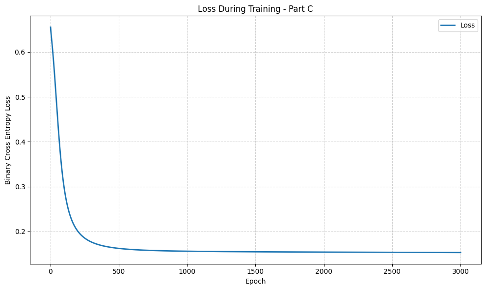

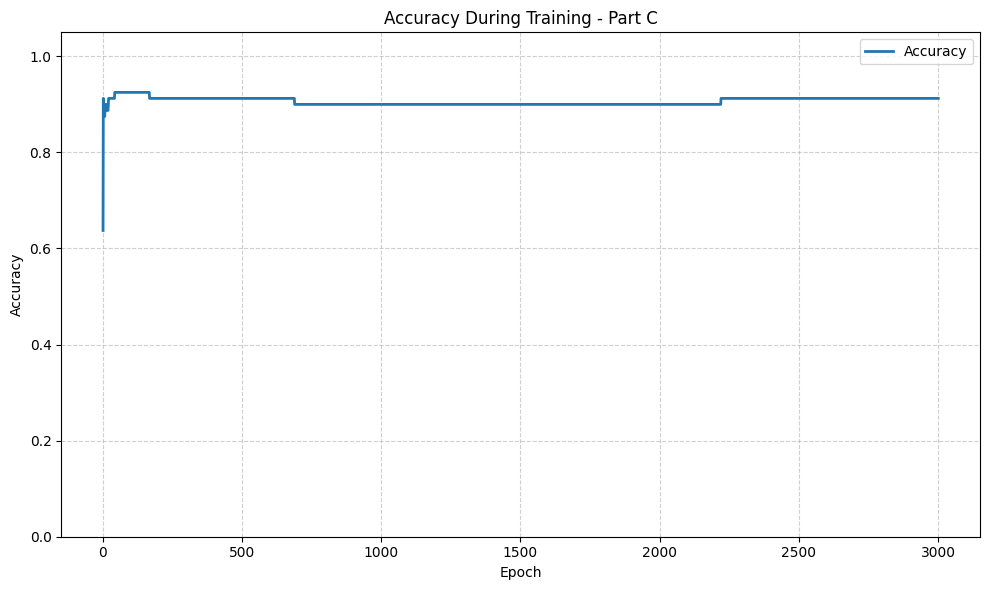

```python
class NeuralNetwork231:
    def __init__(self, input_size=2, hidden_size=3, output_size=1):
        # Random weight initialization
        self.weights_input_hidden = np.random.randn(input_size, hidden_size)
        self.bias_hidden = np.zeros((1, hidden_size))

        self.weights_hidden_output = np.random.randn(hidden_size, output_size)
        self.bias_output = np.zeros((1, output_size))

    def sigmoid(self, x):
        return 1 / (1 + np.exp(-x))

    def sigmoid_derivative(self, sigmoid_output):
        return sigmoid_output * (1 - sigmoid_output)

    def forward(self, X):
        # Hidden layer
        self.hidden_layer = self.sigmoid(
            np.dot(X, self.weights_input_hidden) + self.bias_hidden
        )

        # Output layer
        self.output = self.sigmoid(
            np.dot(self.hidden_layer, self.weights_hidden_output) + self.bias_output
        )

        return self.output

    def binary_cross_entropy(self, y_true, y_pred):
        epsilon = 1e-9
        y_pred = np.clip(y_pred, epsilon, 1 - epsilon)

        return -np.mean(
            y_true * np.log(y_pred) + (1 - y_true) * np.log(1 - y_pred)
        )

    def train(self, X, y, epochs=3000, learning_rate=1.0):
        loss_history = []
        accuracy_history = []

        n_samples = X.shape[0]

        for _ in range(epochs):
            # Forward propagation
            output = self.forward(X)

            # Metrics
            loss = self.binary_cross_entropy(y, output)
            predicted_classes = (output >= 0.5).astype(int)
            accuracy = np.mean(predicted_classes == y)

            loss_history.append(loss)
            accuracy_history.append(accuracy)

            # Backpropagation for sigmoid + BCE
            output_delta = y - output

            hidden_error = np.dot(output_delta, self.weights_hidden_output.T)
            hidden_delta = hidden_error * self.sigmoid_derivative(self.hidden_layer)

            # Weight and bias updates
            # We divide by n_samples in order to use the average gradient.
            self.weights_hidden_output += learning_rate * np.dot(
                self.hidden_layer.T, output_delta
            ) / n_samples

            self.bias_output += learning_rate * np.sum(
                output_delta, axis=0, keepdims=True
            ) / n_samples

            self.weights_input_hidden += learning_rate * np.dot(
                X.T, hidden_delta
            ) / n_samples

            self.bias_hidden += learning_rate * np.sum(
                hidden_delta, axis=0, keepdims=True
            ) / n_samples

        return np.array(loss_history), np.array(accuracy_history)


# -----------------------------
# Synthetic dataset for part C
# -----------------------------

np.random.seed(42)

n_per_class = 40

# Class 0: lower noise and vibration values
class_0 = np.random.normal(
    loc=[0.35, 0.35],
    scale=[0.16, 0.16],
    size=(n_per_class, 2)
)

# Class 1: higher noise and vibration values
class_1 = np.random.normal(
    loc=[0.65, 0.65],
    scale=[0.16, 0.16],
    size=(n_per_class, 2)
)

X_classification = np.vstack([class_0, class_1])
X_classification = np.clip(X_classification, 0, 1)

y_classification = np.vstack([
    np.zeros((n_per_class, 1)),
    np.ones((n_per_class, 1))
])

dataset_c = pd.DataFrame(
    np.hstack([X_classification, y_classification]),
    columns=["x1_noise_level", "x2_vibration_level", "target"]
)

print("Synthetic dataset shape:", dataset_c.shape)
print("\nFirst 10 rows of the dataset:")
display(dataset_c.head(10))

print("\nClass distribution:")
print(dataset_c["target"].value_counts().sort_index())


# Plot the synthetic classification dataset
plt.figure(figsize=(7, 6))

plt.scatter(
    X_classification[y_classification.flatten() == 0, 0],
    X_classification[y_classification.flatten() == 0, 1],
    label="Class 0 - Normal"
)

plt.scatter(
    X_classification[y_classification.flatten() == 1, 0],
    X_classification[y_classification.flatten() == 1, 1],
    label="Class 1 - Abnormal"
)

plt.title("Synthetic Classification Dataset")
plt.xlabel("x1 - Noise Level")
plt.ylabel("x2 - Vibration Level")
plt.legend()
plt.grid(True, linestyle="--", alpha=0.6)
plt.tight_layout()
plt.show()


# -----------------------------
# Training the 2-3-1 network
# -----------------------------

EPOCHS_C = 3000
LEARNING_RATE_C = 1.0

np.random.seed(7)

nn_c = NeuralNetwork231(input_size=2, hidden_size=3, output_size=1)

loss_history_c, accuracy_history_c = nn_c.train(
    X_classification,
    y_classification,
    epochs=EPOCHS_C,
    learning_rate=LEARNING_RATE_C
)

final_predictions_c = nn_c.forward(X_classification)
final_classes_c = (final_predictions_c >= 0.5).astype(int)

final_loss_c = nn_c.binary_cross_entropy(y_classification, final_predictions_c)
final_accuracy_c = np.mean(final_classes_c == y_classification)

print("\n--- Training Results For Part C ---")
print(f"Epochs: {EPOCHS_C}")
print(f"Learning rate: {LEARNING_RATE_C}")
print(f"Final loss: {final_loss_c:.4f}")
print(f"Final accuracy: {final_accuracy_c:.4f}")

print("\nFirst 10 predictions:")
for i in range(10):
    print(
        f"x = {X_classification[i]} | "
        f"prediction = {final_predictions_c[i][0]:.4f} | "
        f"class = {final_classes_c[i][0]} | "
        f"target = {int(y_classification[i][0])}"
    )


# Plot convergence: Loss and Accuracy over epochs
epochs_axis_c = np.arange(1, EPOCHS_C + 1)

plt.figure(figsize=(10, 6))
plt.plot(epochs_axis_c, loss_history_c, linewidth=2, label="Loss")
plt.title("Loss During Training - Part C")
plt.xlabel("Epoch")
plt.ylabel("Binary Cross Entropy Loss")
plt.legend()
plt.grid(True, linestyle="--", alpha=0.6)
plt.tight_layout()
plt.show()

plt.figure(figsize=(10, 6))
plt.plot(epochs_axis_c, accuracy_history_c, linewidth=2, label="Accuracy")
plt.title("Accuracy During Training - Part C")
plt.xlabel("Epoch")
plt.ylabel("Accuracy")
plt.ylim(0, 1.05)
plt.legend()
plt.grid(True, linestyle="--", alpha=0.6)
plt.tight_layout()
plt.show()
```

#### **סיכום תוצאות סעיף ג**

בסעיף זה יצרנו דאטאסט סינתטי קטן עבור בעיית הקלאסיפיקציה שתוארה בסעיף א.

הדאטאסט כולל 80 דוגמאות ו־3 עמודות:

| Column | Description |
| --- | --- |
| `x1_noise_level` | רמת רעש |
| `x2_vibration_level` | רמת רעידות |
| `target` | תווית המחלקה: 0 עבור מצב תקין, 1 עבור מצב חריג |

התפלגות המחלקות בדאטאסט מאוזנת:

| Class | Number of samples |
| --- | --- |
| 0 | 40 |
| 1 | 40 |

כלומר, אין כאן בעיית imbalance בין המחלקות, ולכן מדד ה־accuracy מתאים להערכת ביצועי המודל.

מהגרף של הדאטאסט ניתן לראות שהמחלקות ניתנות להפרדה באופן חלקי: רוב הדוגמאות של המחלקה התקינה נמצאות באזור ערכים נמוכים יותר של רעש ורעידות, ואילו רוב הדוגמאות של המחלקה החריגה נמצאות באזור ערכים גבוהים יותר. עם זאת, קיימת חפיפה מסוימת בין המחלקות, ולכן הבעיה אינה טריוויאלית לחלוטין.

לאחר אימון הרשת במבנה:

$$ 2 \rightarrow 3 \rightarrow 1 $$

התקבלו התוצאות הבאות:

| Metric | Value |
| --- | --- |
| Epochs | 3000 |
| Learning Rate | 1.0 |
| Final Loss | 0.1531 |
| Final Accuracy | 0.9125 |

כלומר, המודל הגיע לדיוק סיווג של 91.25% ול־Loss סופי של: 0.1531

מגרף ה־Loss ניתן לראות שתהליך ההתכנסות תקין: בתחילת האימון ה־Loss יורד בצורה חדה, ולאחר מכן הירידה נעשית מתונה יותר עד להתייצבות. התנהגות זו אופיינית לאימון רשת נוירונים, כאשר בתחילת האימון המודל מבצע תיקונים גדולים יחסית במשקולות, ולאחר מכן מתקרב בהדרגה לאזור מינימום של פונקציית ההפסד.

מגרף ה־Accuracy ניתן לראות שהדיוק עולה במהירות בתחילת האימון ומתייצב סביב ערך של כ־91%. כלומר, הרשת לומדת מהר יחסית את ההפרדה המרכזית בין המחלקות, אך אינה מגיעה ל־100% דיוק בגלל החפיפה הקיימת בין הדוגמאות של שתי המחלקות.

ניתן לראות זאת גם בתחזיות הראשונות. רוב הדוגמאות מסווגות נכון, אך קיימות דוגמאות של מחלקה 0 שהמודל מסווג כמחלקה 1. לדוגמה:

| Input | Prediction | Predicted Class | Target |
| --- | --- | --- | --- |
| $[0.4536,\ 0.5937]$ | 0.6889 | 1 | 0 |
| $[0.6027,\ 0.4728]$ | 0.7435 | 1 | 0 |

שתי הדוגמאות האלו שייכות למחלקה 0, אך הערכים שלהן יחסית גבוהים ולכן הן נמצאות באזור קרוב למחלקה 1. לכן המודל מסווג אותן בטעות כמחלקה חריגה.

המסקנה היא שהרשת מצליחה ללמוד את בעיית הקלאסיפיקציה בצורה טובה, אך לא מושלמת. ה־Loss יורד בצורה יציבה לאורך האפוקים, וה־Accuracy מתייצב על ערך גבוה יחסית. מכיוון שהדאטאסט כולל חפיפה בין המחלקות, התוצאה של 91.25% דיוק היא סבירה ומשקפת בעיית סיווג שאינה מופרדת באופן מושלם.

#### **ד. שינוי הדאטאסט כך שתהליך ההתכנסות ישתפר**

בסעיף זה נשנה את הדאטאסט מסעיף ג כך שתהליך ההתכנסות של הרשת ישתפר.

המטרה כאן אינה רק לקבל דיוק סופי גבוה יותר, אלא להראות שתהליך הלמידה עצמו נעשה טוב יותר. כלומר, נבדוק האם ה־Loss יורד מהר יותר, האם ה־Accuracy עולה מהר יותר, והאם המודל מגיע לערכי ביצוע טובים תוך פחות אפוקים.

כדי לבודד את השפעת הדאטאסט בלבד, נשאיר את אותם תנאי אימון כמו בסעיף ג:

$$ \text{Network structure} = 2 \rightarrow 3 \rightarrow 1 $$

$$ \text{Epochs} = 3000 $$

$$ \text{Learning Rate} = 1.0 $$

השינוי שנבצע בדאטאסט הוא הגדלת ההפרדה בין המחלקות והקטנת הפיזור שלהן.

בסעיף ג המחלקות היו קרובות יחסית וחפפו חלקית:

$$ \mu_0 = (0.35,\ 0.35), \quad \mu_1 = (0.65,\ 0.65), \quad \sigma = 0.16 $$

בסעיף זה ניצור דאטאסט ברור יותר:

$$ \mu_0 = (0.25,\ 0.25), \quad \mu_1 = (0.75,\ 0.75), \quad \sigma = 0.08 $$

כלומר, המחלקות רחוקות יותר זו מזו וכל מחלקה מרוכזת יותר סביב המרכז שלה. לכן גבול ההחלטה בין המחלקות ברור יותר, ונצפה שתהליך ההתכנסות יהיה מהיר ויציב יותר לעומת סעיף ג.

```
Improved synthetic dataset shape: (80, 3)

First 10 rows of the improved dataset:
```

|  | x1_noise_level | x2_vibration_level | target |
| --- | --- | --- | --- |
| 0 | 0.289737 | 0.238939 | 0.0 |
| 1 | 0.301815 | 0.371842 | 0.0 |
| 2 | 0.231268 | 0.231269 | 0.0 |
| 3 | 0.376337 | 0.311395 | 0.0 |
| 4 | 0.212442 | 0.293405 | 0.0 |
| 5 | 0.212927 | 0.212742 | 0.0 |
| 6 | 0.269357 | 0.096938 | 0.0 |
| 7 | 0.112007 | 0.205017 | 0.0 |
| 8 | 0.168974 | 0.275140 | 0.0 |
| 9 | 0.177358 | 0.137016 | 0.0 |

```
Class distribution:
target
0.0    40
1.0    40
Name: count, dtype: int64
```

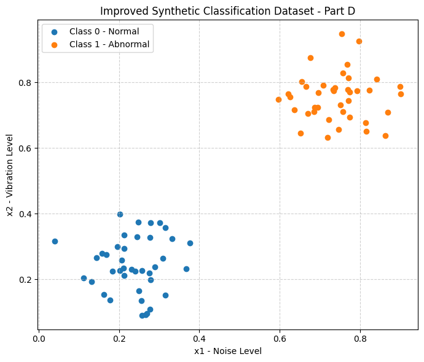

```
--- Training Results For Part D ---
Epochs: 3000
Learning rate: 1.0
Final loss: 0.0009
Final accuracy: 1.0000

First 10 predictions:
x = [0.28973713 0.23893886] | prediction = 0.0007 | class = 0 | target = 0
x = [0.30181508 0.37184239] | prediction = 0.0038 | class = 0 | target = 0
x = [0.23126773 0.23126904] | prediction = 0.0004 | class = 0 | target = 0
x = [0.37633703 0.31139478] | prediction = 0.0050 | class = 0 | target = 0
x = [0.21244205 0.2934048 ] | prediction = 0.0005 | class = 0 | target = 0
x = [0.21292658 0.21274162] | prediction = 0.0003 | class = 0 | target = 0
x = [0.26935698 0.09693758] | prediction = 0.0002 | class = 0 | target = 0
x = [0.11200657 0.205017  ] | prediction = 0.0001 | class = 0 | target = 0
x = [0.16897351 0.27513979] | prediction = 0.0003 | class = 0 | target = 0
x = [0.17735807 0.1370157 ] | prediction = 0.0001 | class = 0 | target = 0
```

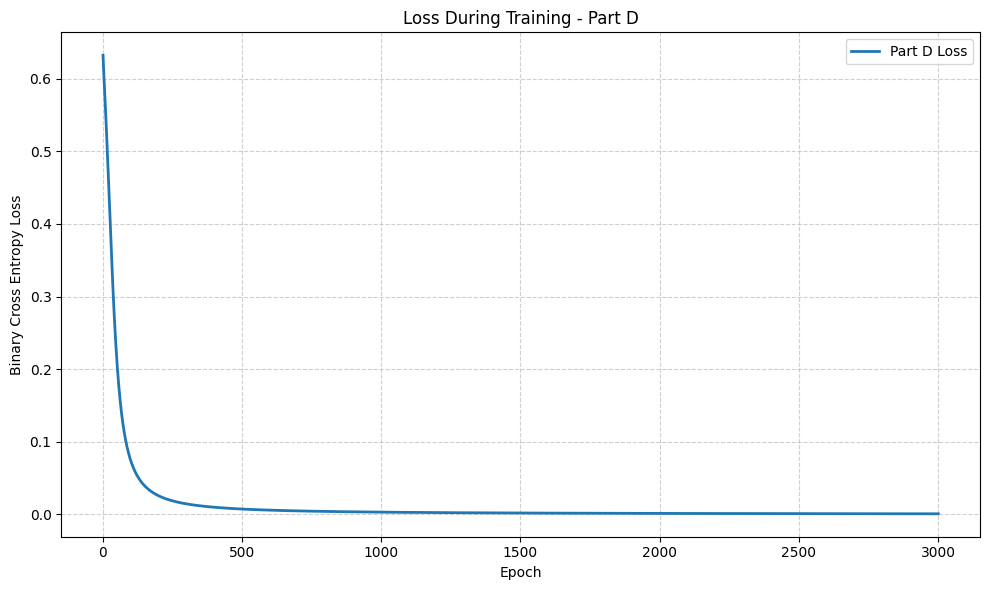

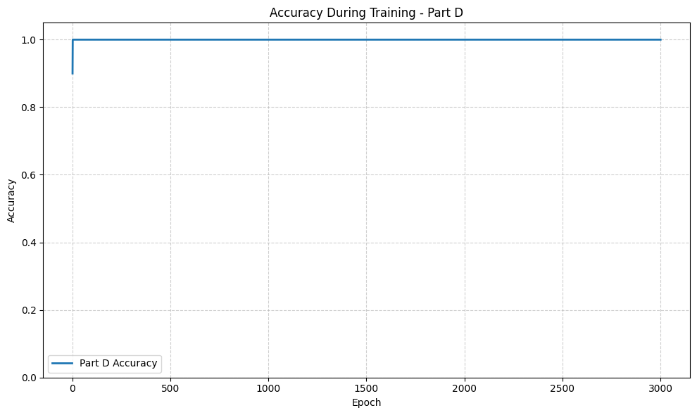

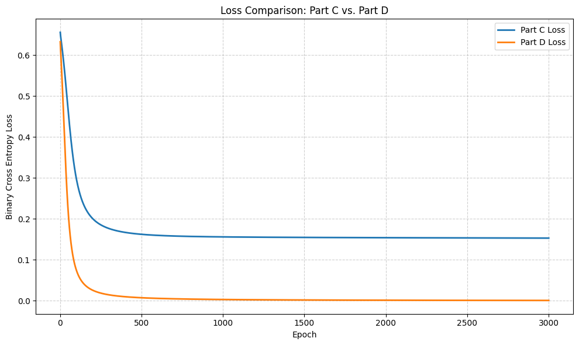

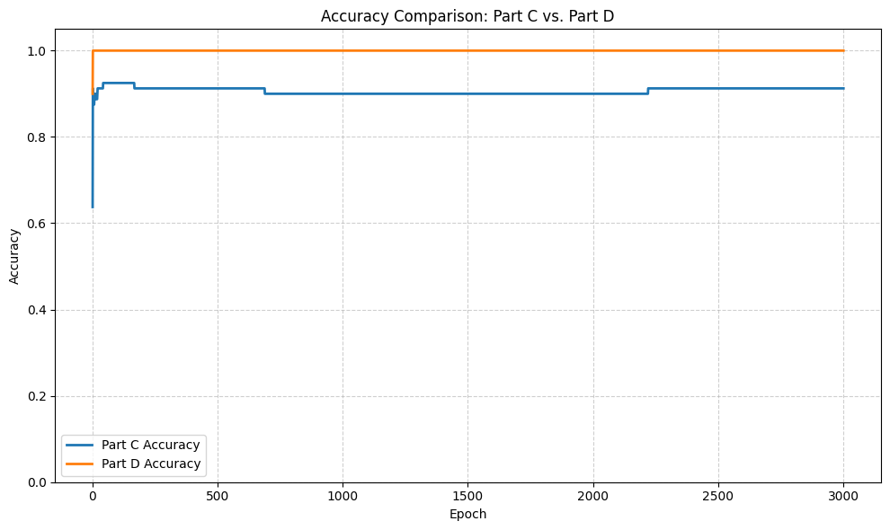

```
--- Convergence Speed Comparison: Part C vs. Part D ---
Metric | Part C | Part D
-------------------------------------------------------
Final loss | 0.1531 | 0.0009
Final accuracy | 0.9125 | 1.0000
First epoch with loss <= 0.20 | 202 | 53
First epoch with loss <= 0.10 | None | 84
First epoch with loss <= 0.05 | None | 129
First epoch with accuracy >= 0.90 | 2 | 1
First epoch with accuracy = 1.00 | None | 2

--- Part D Checkpoints ---
Epoch | Loss | Accuracy
-----------------------------------
    1 | 0.6323 | 0.9000
   10 | 0.5571 | 1.0000
   25 | 0.4179 | 1.0000
   50 | 0.2156 | 1.0000
  100 | 0.0746 | 1.0000
  250 | 0.0188 | 1.0000
  500 | 0.0074 | 1.0000
 1000 | 0.0032 | 1.0000
 2000 | 0.0014 | 1.0000
 3000 | 0.0009 | 1.0000
```

```python
# -----------------------------
# Part D: Improve the dataset to improve convergence
# -----------------------------

np.random.seed(42)

n_per_class = 40

# Improved dataset:
# Compared to Part C, the class centers are farther apart
# and the variance inside each class is smaller.
class_0_d = np.random.normal(
    loc=[0.25, 0.25],
    scale=[0.08, 0.08],
    size=(n_per_class, 2)
)

class_1_d = np.random.normal(
    loc=[0.75, 0.75],
    scale=[0.08, 0.08],
    size=(n_per_class, 2)
)

X_improved = np.vstack([class_0_d, class_1_d])
X_improved = np.clip(X_improved, 0, 1)

y_improved = np.vstack([
    np.zeros((n_per_class, 1)),
    np.ones((n_per_class, 1))
])

dataset_d = pd.DataFrame(
    np.hstack([X_improved, y_improved]),
    columns=["x1_noise_level", "x2_vibration_level", "target"]
)

print("Improved synthetic dataset shape:", dataset_d.shape)
print("\nFirst 10 rows of the improved dataset:")
display(dataset_d.head(10))

print("\nClass distribution:")
print(dataset_d["target"].value_counts().sort_index())


# -----------------------------
# Plot improved dataset
# -----------------------------

plt.figure(figsize=(7, 6))

plt.scatter(
    X_improved[y_improved.flatten() == 0, 0],
    X_improved[y_improved.flatten() == 0, 1],
    label="Class 0 - Normal"
)

plt.scatter(
    X_improved[y_improved.flatten() == 1, 0],
    X_improved[y_improved.flatten() == 1, 1],
    label="Class 1 - Abnormal"
)

plt.title("Improved Synthetic Classification Dataset - Part D")
plt.xlabel("x1 - Noise Level")
plt.ylabel("x2 - Vibration Level")
plt.legend()
plt.grid(True, linestyle="--", alpha=0.6)
plt.tight_layout()
plt.show()


# -----------------------------
# Train the same 2-3-1 network
# -----------------------------

EPOCHS_D = 3000
LEARNING_RATE_D = 1.0

np.random.seed(7)

nn_d = NeuralNetwork231(input_size=2, hidden_size=3, output_size=1)

loss_history_d, accuracy_history_d = nn_d.train(
    X_improved,
    y_improved,
    epochs=EPOCHS_D,
    learning_rate=LEARNING_RATE_D
)

final_predictions_d = nn_d.forward(X_improved)
final_classes_d = (final_predictions_d >= 0.5).astype(int)

final_loss_d = nn_d.binary_cross_entropy(y_improved, final_predictions_d)
final_accuracy_d = np.mean(final_classes_d == y_improved)

print("\n--- Training Results For Part D ---")
print(f"Epochs: {EPOCHS_D}")
print(f"Learning rate: {LEARNING_RATE_D}")
print(f"Final loss: {final_loss_d:.4f}")
print(f"Final accuracy: {final_accuracy_d:.4f}")

print("\nFirst 10 predictions:")
for i in range(10):
    print(
        f"x = {X_improved[i]} | "
        f"prediction = {final_predictions_d[i][0]:.4f} | "
        f"class = {final_classes_d[i][0]} | "
        f"target = {int(y_improved[i][0])}"
    )


# -----------------------------
# Plot convergence for Part D
# -----------------------------

epochs_axis_d = np.arange(1, EPOCHS_D + 1)

plt.figure(figsize=(10, 6))
plt.plot(epochs_axis_d, loss_history_d, linewidth=2, label="Part D Loss")
plt.title("Loss During Training - Part D")
plt.xlabel("Epoch")
plt.ylabel("Binary Cross Entropy Loss")
plt.legend()
plt.grid(True, linestyle="--", alpha=0.6)
plt.tight_layout()
plt.show()

plt.figure(figsize=(10, 6))
plt.plot(epochs_axis_d, accuracy_history_d, linewidth=2, label="Part D Accuracy")
plt.title("Accuracy During Training - Part D")
plt.xlabel("Epoch")
plt.ylabel("Accuracy")
plt.ylim(0, 1.05)
plt.legend()
plt.grid(True, linestyle="--", alpha=0.6)
plt.tight_layout()
plt.show()


# -----------------------------
# Compare convergence with Part C
# -----------------------------

epochs_axis_c = np.arange(1, len(loss_history_c) + 1)

plt.figure(figsize=(10, 6))
plt.plot(epochs_axis_c, loss_history_c, linewidth=2, label="Part C Loss")
plt.plot(epochs_axis_d, loss_history_d, linewidth=2, label="Part D Loss")
plt.title("Loss Comparison: Part C vs. Part D")
plt.xlabel("Epoch")
plt.ylabel("Binary Cross Entropy Loss")
plt.legend()
plt.grid(True, linestyle="--", alpha=0.6)
plt.tight_layout()
plt.show()

plt.figure(figsize=(10, 6))
plt.plot(epochs_axis_c, accuracy_history_c, linewidth=2, label="Part C Accuracy")
plt.plot(epochs_axis_d, accuracy_history_d, linewidth=2, label="Part D Accuracy")
plt.title("Accuracy Comparison: Part C vs. Part D")
plt.xlabel("Epoch")
plt.ylabel("Accuracy")
plt.ylim(0, 1.05)
plt.legend()
plt.grid(True, linestyle="--", alpha=0.6)
plt.tight_layout()
plt.show()


# -----------------------------
# Convergence speed metrics
# -----------------------------

def first_epoch_at_or_below(values, threshold):
    values = np.array(values)
    indices = np.where(values <= threshold)[0]
    if len(indices) == 0:
        return None
    return int(indices[0] + 1)


def first_epoch_at_or_above(values, threshold):
    values = np.array(values)
    indices = np.where(values >= threshold)[0]
    if len(indices) == 0:
        return None
    return int(indices[0] + 1)


part_c_loss_below_020 = first_epoch_at_or_below(loss_history_c, 0.20)
part_d_loss_below_020 = first_epoch_at_or_below(loss_history_d, 0.20)

part_c_loss_below_010 = first_epoch_at_or_below(loss_history_c, 0.10)
part_d_loss_below_010 = first_epoch_at_or_below(loss_history_d, 0.10)

part_c_loss_below_005 = first_epoch_at_or_below(loss_history_c, 0.05)
part_d_loss_below_005 = first_epoch_at_or_below(loss_history_d, 0.05)

part_c_acc_above_090 = first_epoch_at_or_above(accuracy_history_c, 0.90)
part_d_acc_above_090 = first_epoch_at_or_above(accuracy_history_d, 0.90)

part_c_acc_equal_100 = first_epoch_at_or_above(accuracy_history_c, 1.00)
part_d_acc_equal_100 = first_epoch_at_or_above(accuracy_history_d, 1.00)

print("\n--- Convergence Speed Comparison: Part C vs. Part D ---")
print("Metric | Part C | Part D")
print("-" * 55)
print(f"Final loss | {final_loss_c:.4f} | {final_loss_d:.4f}")
print(f"Final accuracy | {final_accuracy_c:.4f} | {final_accuracy_d:.4f}")
print(f"First epoch with loss <= 0.20 | {part_c_loss_below_020} | {part_d_loss_below_020}")
print(f"First epoch with loss <= 0.10 | {part_c_loss_below_010} | {part_d_loss_below_010}")
print(f"First epoch with loss <= 0.05 | {part_c_loss_below_005} | {part_d_loss_below_005}")
print(f"First epoch with accuracy >= 0.90 | {part_c_acc_above_090} | {part_d_acc_above_090}")
print(f"First epoch with accuracy = 1.00 | {part_c_acc_equal_100} | {part_d_acc_equal_100}")


# -----------------------------
# Checkpoint table
# -----------------------------

checkpoints = [1, 10, 25, 50, 100, 250, 500, 1000, 2000, 3000]

print("\n--- Part D Checkpoints ---")
print("Epoch | Loss | Accuracy")
print("-" * 35)

for epoch in checkpoints:
    print(
        f"{epoch:5d} | "
        f"{loss_history_d[epoch - 1]:.4f} | "
        f"{accuracy_history_d[epoch - 1]:.4f}"
    )
```

#### **סיכום תוצאות סעיף ד**

בסעיף זה שינינו את הדאטאסט מסעיף ג במטרה לשפר את תהליך ההתכנסות של הרשת.

השינוי שבוצע בדאטאסט היה הגדלת ההפרדה בין המחלקות והקטנת הפיזור הפנימי שלהן:

| Dataset | Class 0 Center | Class 1 Center | Standard Deviation |
| --- | --- | --- | --- |
| Part C | $(0.35,\ 0.35)$ | $(0.65,\ 0.65)$ | $0.16$ |
| Part D | $(0.25,\ 0.25)$ | $(0.75,\ 0.75)$ | $0.08$ |

כלומר, בדאטאסט החדש המחלקות רחוקות יותר זו מזו, וכל מחלקה מרוכזת יותר סביב המרכז שלה. כתוצאה מכך גבול ההחלטה בין המחלקות ברור יותר, והרשת יכולה ללמוד אותו מהר יותר.

כדי לבדוק את השיפור בהתכנסות, השארנו את תנאי האימון זהים לסעיף ג:

$$ \text{Network structure} = 2 \rightarrow 3 \rightarrow 1 $$

$$ \text{Epochs} = 3000 $$

$$ \text{Learning Rate} = 1.0 $$

התוצאות הסופיות היו:

| Metric | Part C | Part D |
| --- | --- | --- |
| Final Loss | 0.1531 | 0.0009 |
| Final Accuracy | 0.9125 | 1.0000 |

אך המדד החשוב יותר בסעיף זה הוא לא רק התוצאה הסופית, אלא קצב ההתכנסות לאורך האפוקים.

השוואת קצב ההתכנסות מראה:

| Convergence Metric | Part C | Part D |
| --- | --- | --- |
| First epoch with loss $\leq 0.20$ | 202 | 53 |
| First epoch with loss $\leq 0.10$ | None | 84 |
| First epoch with loss $\leq 0.05$ | None | 129 |
| First epoch with accuracy $\geq 0.90$ | 2 | 1 |
| First epoch with accuracy $= 1.00$ | None | 2 |

ניתן לראות שבסעיף ד הרשת מגיעה לערכי Loss נמוכים הרבה יותר ובפחות אפוקים. לדוגמה, כדי להגיע ל־Loss קטן או שווה ל־0.20, בסעיף ג נדרשו 202 אפוקים, ואילו בסעיף ד נדרשו רק 53 אפוקים. בנוסף, בסעיף ג הרשת כלל לא הגיעה ל־Loss קטן מ־0.10 או 0.05 במהלך 3000 אפוקים, בעוד שבסעיף ד היא הגיעה לערכים אלו כבר באפוקים 84 ו־129.

גם מבחינת Accuracy יש שיפור ברור בהתכנסות: בסעיף ד הרשת הגיעה לדיוק של 100% כבר באפוק 2, בעוד שבסעיף ג היא לא הגיעה ל־100% דיוק כלל במהלך 3000 אפוקים.

טבלת נקודות הבדיקה בסעיף ד מדגישה את קצב ההתכנסות המהיר:

| Epoch | Loss | Accuracy |
| --- | --- | --- |
| 1 | 0.6323 | 0.9000 |
| 10 | 0.5571 | 1.0000 |
| 25 | 0.4179 | 1.0000 |
| 50 | 0.2156 | 1.0000 |
| 100 | 0.0746 | 1.0000 |
| 250 | 0.0188 | 1.0000 |
| 500 | 0.0074 | 1.0000 |
| 1000 | 0.0032 | 1.0000 |
| 2000 | 0.0014 | 1.0000 |
| 3000 | 0.0009 | 1.0000 |

מהטבלה ניתן לראות שגם לאחר שה־Accuracy מגיע ל־100%, ה־Loss ממשיך לרדת. כלומר, הרשת לא רק מסווגת נכון את הדוגמאות, אלא גם נעשית בטוחה יותר בתחזיות שלה: הפלטים עבור מחלקה 0 מתקרבים יותר ל־0, והפלטים עבור מחלקה 1 מתקרבים יותר ל־1.

המסקנה היא שהשינוי בדאטאסט אכן שיפר את תהליך ההתכנסות. הגדלת המרחק בין המחלקות והקטנת הפיזור הפחיתו את החפיפה בין המחלקות, ולכן הרשת הצליחה ללמוד גבול החלטה ברור יותר, מהר יותר ובצורה יציבה יותר.

#### **ה. שינוי הדאטאסט כך שתהליך ההתכנסות יהיה איטי יותר באופן משמעותי**

בסעיף זה נשנה את הדאטאסט שיצרנו בסעיף ג כך שתהליך ההתכנסות יהיה איטי יותר באופן משמעותי.

המטרה כאן אינה ליצור דאטאסט בלתי ניתן ללמידה, אלא ליצור דאטאסט שבו הרשת עדיין יכולה ללמוד את ההפרדה בין המחלקות, אך נדרשים לה יותר אפוקים כדי להגיע ל־Loss נמוך.

בסעיף ג השתמשנו במחלקות עם מרכזים יחסית רחוקים ופיזור בינוני:

$$ \mu_0 = (0.35,\ 0.35), \quad \mu_1 = (0.65,\ 0.65), \quad \sigma = 0.16 $$

בסעיף זה ניצור דאטאסט שבו שתי המחלקות קרובות הרבה יותר זו לזו, אך עם פיזור קטן, כך שהן עדיין ניתנות להפרדה:

$$ \mu_0 = (0.46,\ 0.46), \quad \mu_1 = (0.54,\ 0.54), \quad \sigma = 0.03 $$

כלומר, המחלקות כמעט נוגעות זו בזו במרחב הקלט. במצב כזה הגבול בין המחלקות קיים, אך ה־margin קטן מאוד. לכן הרשת צריכה ללמוד מעבר חד ועדין יותר בין מחלקה 0 למחלקה 1.

חשוב לציין ש־Accuracy הוא מדד גס יחסית, משום שהוא תלוי רק בשאלה האם הפלט עבר את סף ההחלטה 0.5. לעומת זאת, ה־Loss מודד גם את רמת הביטחון של המודל בתחזיות שלו. לכן בסעיף זה נבחן בעיקר האם ה־Loss יורד לאט יותר, וכמה אפוקים נדרשים כדי להגיע לערכי Loss נמוכים.

תנאי האימון יישארו זהים לסעיפים הקודמים:

$$ \text{Network structure} = 2 \rightarrow 3 \rightarrow 1 $$

$$ \text{Epochs} = 3000 $$

$$ \text{Learning Rate} = 1.0 $$

```
Slower-convergence synthetic dataset shape: (80, 3)

First 10 rows of the slower-convergence dataset:
```

|  | x1_noise_level | x2_vibration_level | target |
| --- | --- | --- | --- |
| 0 | 0.474901 | 0.455852 | 0.0 |
| 1 | 0.479431 | 0.505691 | 0.0 |
| 2 | 0.452975 | 0.452976 | 0.0 |
| 3 | 0.507376 | 0.483023 | 0.0 |
| 4 | 0.445916 | 0.476277 | 0.0 |
| 5 | 0.446097 | 0.446028 | 0.0 |
| 6 | 0.467259 | 0.402602 | 0.0 |
| 7 | 0.408252 | 0.443131 | 0.0 |
| 8 | 0.429615 | 0.469427 | 0.0 |
| 9 | 0.432759 | 0.417631 | 0.0 |

```
Class distribution:
target
0.0    40
1.0    40
Name: count, dtype: int64
```

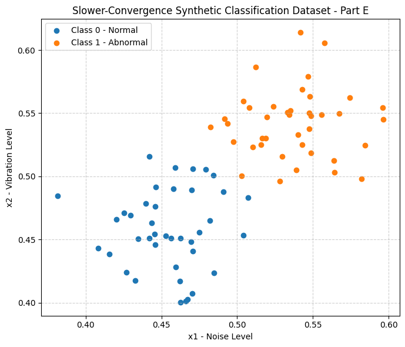

```
--- Training Results For Part E ---
Epochs: 3000
Learning rate: 1.0
Final loss: 0.0327
Final accuracy: 1.0000

First 10 predictions:
x = [0.47490142 0.45585207] | prediction = 0.0033 | class = 0 | target = 0
x = [0.47943066 0.5056909 ] | prediction = 0.2124 | class = 0 | target = 0
x = [0.4529754  0.45297589] | prediction = 0.0005 | class = 0 | target = 0
x = [0.50737638 0.48302304] | prediction = 0.2961 | class = 0 | target = 0
x = [0.44591577 0.4762768 ] | prediction = 0.0017 | class = 0 | target = 0
x = [0.44609747 0.44602811] | prediction = 0.0002 | class = 0 | target = 0
x = [0.46725887 0.40260159] | prediction = 0.0001 | class = 0 | target = 0
x = [0.40825247 0.44313137] | prediction = 0.0000 | class = 0 | target = 0
x = [0.42961507 0.46942742] | prediction = 0.0003 | class = 0 | target = 0
x = [0.43275928 0.41763089] | prediction = 0.0000 | class = 0 | target = 0
```

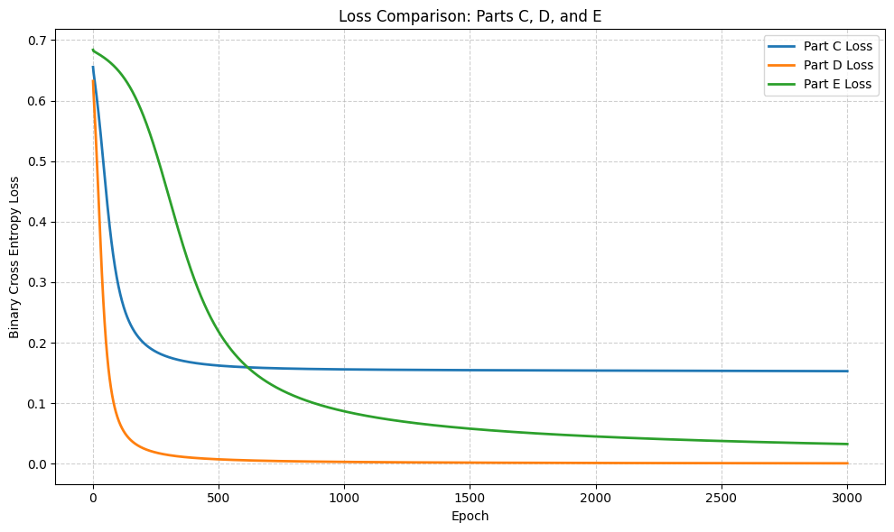

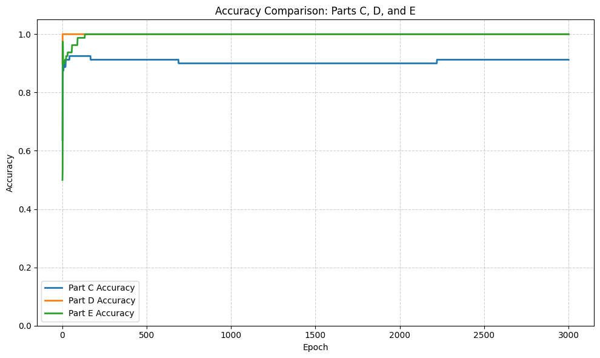

```
--- Convergence Speed Comparison ---
Metric | Part C | Part D | Part E
--------------------------------------------------------------------------------
Final loss | 0.1531 | 0.0009 | 0.0327
Final accuracy | 0.9125 | 1.0000 | 1.0000
First epoch with loss <= 0.20 | 202 | 53 | 530
First epoch with loss <= 0.15 | None | 65 | 643
First epoch with loss <= 0.10 | None | 84 | 882
First epoch with loss <= 0.05 | None | 129 | 1775
First epoch with accuracy >= 0.90 | 2 | 1 | 3
First epoch with accuracy = 1.00 | None | 2 | 134

--- Part E Checkpoints ---
Epoch | Loss | Accuracy
-----------------------------------
    1 | 0.6838 | 0.5000
   10 | 0.6801 | 0.9000
   25 | 0.6764 | 0.9250
   50 | 0.6693 | 0.9375
  100 | 0.6502 | 0.9875
  250 | 0.5162 | 1.0000
  500 | 0.2185 | 1.0000
 1000 | 0.0867 | 1.0000
 2000 | 0.0452 | 1.0000
 3000 | 0.0327 | 1.0000
```

```python
# -----------------------------
# Part E: Change the Part C dataset to make convergence slower
# -----------------------------

np.random.seed(42)

n_per_class = 40

# Slower-convergence dataset:
# Compared to Part C, the classes are closer to each other.
# The dataset is still learnable, but the margin between the classes is smaller.
class_0_e = np.random.normal(
    loc=[0.46, 0.46],
    scale=[0.03, 0.03],
    size=(n_per_class, 2)
)

class_1_e = np.random.normal(
    loc=[0.54, 0.54],
    scale=[0.03, 0.03],
    size=(n_per_class, 2)
)

X_slow = np.vstack([class_0_e, class_1_e])
X_slow = np.clip(X_slow, 0, 1)

y_slow = np.vstack([
    np.zeros((n_per_class, 1)),
    np.ones((n_per_class, 1))
])

dataset_e = pd.DataFrame(
    np.hstack([X_slow, y_slow]),
    columns=["x1_noise_level", "x2_vibration_level", "target"]
)

print("Slower-convergence synthetic dataset shape:", dataset_e.shape)
print("\nFirst 10 rows of the slower-convergence dataset:")
display(dataset_e.head(10))

print("\nClass distribution:")
print(dataset_e["target"].value_counts().sort_index())


# -----------------------------
# Plot Part E dataset
# -----------------------------

plt.figure(figsize=(7, 6))

plt.scatter(
    X_slow[y_slow.flatten() == 0, 0],
    X_slow[y_slow.flatten() == 0, 1],
    label="Class 0 - Normal"
)

plt.scatter(
    X_slow[y_slow.flatten() == 1, 0],
    X_slow[y_slow.flatten() == 1, 1],
    label="Class 1 - Abnormal"
)

plt.title("Slower-Convergence Synthetic Classification Dataset - Part E")
plt.xlabel("x1 - Noise Level")
plt.ylabel("x2 - Vibration Level")
plt.legend()
plt.grid(True, linestyle="--", alpha=0.6)
plt.tight_layout()
plt.show()


# -----------------------------
# Train the same 2-3-1 network
# -----------------------------

EPOCHS_E = 3000
LEARNING_RATE_E = 1.0

np.random.seed(7)

nn_e = NeuralNetwork231(input_size=2, hidden_size=3, output_size=1)

loss_history_e, accuracy_history_e = nn_e.train(
    X_slow,
    y_slow,
    epochs=EPOCHS_E,
    learning_rate=LEARNING_RATE_E
)

final_predictions_e = nn_e.forward(X_slow)
final_classes_e = (final_predictions_e >= 0.5).astype(int)

final_loss_e = nn_e.binary_cross_entropy(y_slow, final_predictions_e)
final_accuracy_e = np.mean(final_classes_e == y_slow)

print("\n--- Training Results For Part E ---")
print(f"Epochs: {EPOCHS_E}")
print(f"Learning rate: {LEARNING_RATE_E}")
print(f"Final loss: {final_loss_e:.4f}")
print(f"Final accuracy: {final_accuracy_e:.4f}")

print("\nFirst 10 predictions:")
for i in range(10):
    print(
        f"x = {X_slow[i]} | "
        f"prediction = {final_predictions_e[i][0]:.4f} | "
        f"class = {final_classes_e[i][0]} | "
        f"target = {int(y_slow[i][0])}"
    )


# -----------------------------
# Combined convergence plots
# -----------------------------

epochs_axis_c = np.arange(1, len(loss_history_c) + 1)
epochs_axis_e = np.arange(1, len(loss_history_e) + 1)

plt.figure(figsize=(10, 6))

plt.plot(epochs_axis_c, loss_history_c, linewidth=2, label="Part C Loss")

if "loss_history_d" in globals():
    epochs_axis_d = np.arange(1, len(loss_history_d) + 1)
    plt.plot(epochs_axis_d, loss_history_d, linewidth=2, label="Part D Loss")

plt.plot(epochs_axis_e, loss_history_e, linewidth=2, label="Part E Loss")

plt.title("Loss Comparison: Parts C, D, and E")
plt.xlabel("Epoch")
plt.ylabel("Binary Cross Entropy Loss")
plt.legend()
plt.grid(True, linestyle="--", alpha=0.6)
plt.tight_layout()
plt.show()


plt.figure(figsize=(10, 6))

plt.plot(epochs_axis_c, accuracy_history_c, linewidth=2, label="Part C Accuracy")

if "accuracy_history_d" in globals():
    epochs_axis_d = np.arange(1, len(accuracy_history_d) + 1)
    plt.plot(epochs_axis_d, accuracy_history_d, linewidth=2, label="Part D Accuracy")

plt.plot(epochs_axis_e, accuracy_history_e, linewidth=2, label="Part E Accuracy")

plt.title("Accuracy Comparison: Parts C, D, and E")
plt.xlabel("Epoch")
plt.ylabel("Accuracy")
plt.ylim(0, 1.05)
plt.legend()
plt.grid(True, linestyle="--", alpha=0.6)
plt.tight_layout()
plt.show()


# -----------------------------
# Convergence speed metrics
# -----------------------------

def first_epoch_at_or_below(values, threshold):
    values = np.array(values)
    indices = np.where(values <= threshold)[0]
    if len(indices) == 0:
        return None
    return int(indices[0] + 1)


def first_epoch_at_or_above(values, threshold):
    values = np.array(values)
    indices = np.where(values >= threshold)[0]
    if len(indices) == 0:
        return None
    return int(indices[0] + 1)


# Part C metrics
part_c_loss_below_020 = first_epoch_at_or_below(loss_history_c, 0.20)
part_c_loss_below_015 = first_epoch_at_or_below(loss_history_c, 0.15)
part_c_loss_below_010 = first_epoch_at_or_below(loss_history_c, 0.10)
part_c_loss_below_005 = first_epoch_at_or_below(loss_history_c, 0.05)
part_c_acc_above_090 = first_epoch_at_or_above(accuracy_history_c, 0.90)
part_c_acc_equal_100 = first_epoch_at_or_above(accuracy_history_c, 1.00)

# Part E metrics
part_e_loss_below_020 = first_epoch_at_or_below(loss_history_e, 0.20)
part_e_loss_below_015 = first_epoch_at_or_below(loss_history_e, 0.15)
part_e_loss_below_010 = first_epoch_at_or_below(loss_history_e, 0.10)
part_e_loss_below_005 = first_epoch_at_or_below(loss_history_e, 0.05)
part_e_acc_above_090 = first_epoch_at_or_above(accuracy_history_e, 0.90)
part_e_acc_equal_100 = first_epoch_at_or_above(accuracy_history_e, 1.00)

print("\n--- Convergence Speed Comparison ---")
print("Metric | Part C | Part D | Part E")
print("-" * 80)

if (
    "loss_history_d" in globals()
    and "accuracy_history_d" in globals()
    and "final_loss_d" in globals()
    and "final_accuracy_d" in globals()
):
    part_d_loss_below_020 = first_epoch_at_or_below(loss_history_d, 0.20)
    part_d_loss_below_015 = first_epoch_at_or_below(loss_history_d, 0.15)
    part_d_loss_below_010 = first_epoch_at_or_below(loss_history_d, 0.10)
    part_d_loss_below_005 = first_epoch_at_or_below(loss_history_d, 0.05)
    part_d_acc_above_090 = first_epoch_at_or_above(accuracy_history_d, 0.90)
    part_d_acc_equal_100 = first_epoch_at_or_above(accuracy_history_d, 1.00)

    print(f"Final loss | {final_loss_c:.4f} | {final_loss_d:.4f} | {final_loss_e:.4f}")
    print(f"Final accuracy | {final_accuracy_c:.4f} | {final_accuracy_d:.4f} | {final_accuracy_e:.4f}")
    print(f"First epoch with loss <= 0.20 | {part_c_loss_below_020} | {part_d_loss_below_020} | {part_e_loss_below_020}")
    print(f"First epoch with loss <= 0.15 | {part_c_loss_below_015} | {part_d_loss_below_015} | {part_e_loss_below_015}")
    print(f"First epoch with loss <= 0.10 | {part_c_loss_below_010} | {part_d_loss_below_010} | {part_e_loss_below_010}")
    print(f"First epoch with loss <= 0.05 | {part_c_loss_below_005} | {part_d_loss_below_005} | {part_e_loss_below_005}")
    print(f"First epoch with accuracy >= 0.90 | {part_c_acc_above_090} | {part_d_acc_above_090} | {part_e_acc_above_090}")
    print(f"First epoch with accuracy = 1.00 | {part_c_acc_equal_100} | {part_d_acc_equal_100} | {part_e_acc_equal_100}")

else:
    print(f"Final loss | {final_loss_c:.4f} | Not available | {final_loss_e:.4f}")
    print(f"Final accuracy | {final_accuracy_c:.4f} | Not available | {final_accuracy_e:.4f}")
    print(f"First epoch with loss <= 0.20 | {part_c_loss_below_020} | Not available | {part_e_loss_below_020}")
    print(f"First epoch with loss <= 0.15 | {part_c_loss_below_015} | Not available | {part_e_loss_below_015}")
    print(f"First epoch with loss <= 0.10 | {part_c_loss_below_010} | Not available | {part_e_loss_below_010}")
    print(f"First epoch with loss <= 0.05 | {part_c_loss_below_005} | Not available | {part_e_loss_below_005}")
    print(f"First epoch with accuracy >= 0.90 | {part_c_acc_above_090} | Not available | {part_e_acc_above_090}")
    print(f"First epoch with accuracy = 1.00 | {part_c_acc_equal_100} | Not available | {part_e_acc_equal_100}")


# -----------------------------
# Part E checkpoint table
# -----------------------------

checkpoints = [1, 10, 25, 50, 100, 250, 500, 1000, 2000, 3000]

print("\n--- Part E Checkpoints ---")
print("Epoch | Loss | Accuracy")
print("-" * 35)

for epoch in checkpoints:
    print(
        f"{epoch:5d} | "
        f"{loss_history_e[epoch - 1]:.4f} | "
        f"{accuracy_history_e[epoch - 1]:.4f}"
    )
```

#### **סיכום תוצאות סעיף ה**

בסעיף זה שינינו את הדאטאסט מסעיף ג כך שתהליך ההתכנסות יהיה איטי יותר באופן משמעותי.

השינוי שבוצע היה הקטנת המרחק בין מרכזי המחלקות, כך שה־margin בין מחלקה 0 למחלקה 1 קטן יותר:

| Dataset | Class 0 Center | Class 1 Center | Standard Deviation |
| --- | --- | --- | --- |
| Part C | $(0.35,\ 0.35)$ | $(0.65,\ 0.65)$ | $0.16$ |
| Part D | $(0.25,\ 0.25)$ | $(0.75,\ 0.75)$ | $0.08$ |
| Part E | $(0.46,\ 0.46)$ | $(0.54,\ 0.54)$ | $0.03$ |

כלומר, בסעיף ה המחלקות עדיין ניתנות להפרדה, אך הן קרובות יותר זו לזו לעומת סעיף ג. לכן הרשת צריכה ללמוד גבול החלטה עדין יותר, וההתכנסות מבחינת ה־Loss נעשית איטית יותר.

לאחר אימון אותה רשת במבנה:

$$ 2 \rightarrow 3 \rightarrow 1 $$

עם אותם תנאי אימון:

$$ \text{Epochs} = 3000, \quad \text{Learning Rate} = 1.0 $$

התקבלו התוצאות הבאות:

| Metric | Part C | Part D | Part E |
| --- | --- | --- | --- |
| Final Loss | 0.1531 | 0.0009 | 0.0327 |
| Final Accuracy | 0.9125 | 1.0000 | 1.0000 |
| First epoch with Loss $\leq 0.20$ | 202 | 53 | 530 |
| First epoch with Loss $\leq 0.15$ | None | 65 | 643 |
| First epoch with Loss $\leq 0.10$ | None | 84 | 882 |
| First epoch with Loss $\leq 0.05$ | None | 129 | 1775 |
| First epoch with Accuracy $\geq 0.90$ | 2 | 1 | 3 |
| First epoch with Accuracy $= 1.00$ | None | 2 | 134 |

מהטבלה ניתן לראות שבסעיף ה תהליך ההתכנסות איטי יותר ביחס לסעיף ג כאשר בוחנים את ה־Loss. לדוגמה, בסעיף ג המודל הגיע ל־Loss קטן או שווה ל־0.20 באפוק 202, ואילו בסעיף ה רק באפוק 530. בנוסף, בסעיף ג המודל כלל לא הגיע ל־Loss קטן או שווה ל־0.15, 0.10 או 0.05 במהלך 3000 אפוקים, בעוד שבסעיף ה הוא כן הגיע לערכים אלו, אך רק לאחר מספר גדול יחסית של אפוקים.

כלומר, סעיף ה אינו “קשה מדי” כמו דאטאסט עם חפיפה חזקה, משום שבסוף האימון המודל מצליח להגיע לדיוק של 100%. עם זאת, הירידה ב־Loss איטית יותר, ולכן ניתן לראות שהמודל צריך יותר אפוקים כדי להגיע לתחזיות בטוחות.

נקודות הבדיקה של סעיף ה מראות את ההתקדמות ההדרגתית:

| Epoch | Loss | Accuracy |
| --- | --- | --- |
| 1 | 0.6838 | 0.5000 |
| 10 | 0.6801 | 0.9000 |
| 25 | 0.6764 | 0.9250 |
| 50 | 0.6693 | 0.9375 |
| 100 | 0.6502 | 0.9875 |
| 250 | 0.5162 | 1.0000 |
| 500 | 0.2185 | 1.0000 |
| 1000 | 0.0867 | 1.0000 |
| 2000 | 0.0452 | 1.0000 |
| 3000 | 0.0327 | 1.0000 |

ניתן לראות שה־Accuracy מגיע לערכים גבוהים יחסית די מוקדם, אך ה־Loss ממשיך לרדת לאורך זמן רב. זה מדגיש את ההבדל בין Accuracy לבין Loss: ה־Accuracy מודד רק האם התחזית עברה את סף ההחלטה הנכון, ואילו ה־Loss מודד גם עד כמה המודל בטוח בתחזית. לכן גם לאחר שהמודל מגיע ל־100% Accuracy, ה־Loss עדיין ממשיך להשתפר.

בגרף ה־Loss ניתן לראות בבירור את ההבדל בין שלושת הדאטאסטים. בסעיף ד ה־Loss יורד מהר מאוד כמעט לאפס, משום שהמחלקות רחוקות וברורות. בסעיף ג ה־Loss יורד מהר יחסית בהתחלה אך מתייצב סביב ערך גבוה יותר, בגלל החפיפה בין המחלקות. בסעיף ה ה־Loss יורד לאט יותר בתחילת האימון, מכיוון שהמחלקות קרובות מאוד וה־margin קטן.

המסקנה היא שהשינוי בדאטאסט בסעיף ה אכן האט את תהליך ההתכנסות. הקטנת המרחק בין המחלקות יצרה גבול החלטה עדין יותר, ולכן הרשת הייתה צריכה יותר אפוקים כדי להגיע ל־Loss נמוך. עם זאת, מכיוון שהמחלקות עדיין ניתנות להפרדה, המודל הצליח בסופו של דבר להגיע לדיוק מלא.